*Note: Sketchy live-tex’d notes, any errors are my own!*

# Automorphic Forms Beyond GL2

Arizona Winter School 2022 Lectures

D. Zack Garza

University of Georgia  
[email protected]

Last updated: 2022-03-09

# 1 Plenary: Akshay Venkatesh

A fairy tale: see [Langlands Elephant](https://www.youtube.com/watch?v=8yRNQIkiudQ). The point of this talk is to see the entire elephant!

In the analogy between number fields and 3-manifolds, automorphic forms are on the number field side – what is the manifold analog? Some history:

- Mazur 63/64, in conversations with Artin: $\operatorname{Spec}{\mathbb{Z}}/p{\mathbb{Z}}\to \operatorname{Spec}{\mathbb{Z}}$ is like a knot in a (simply connected) 3-manifold.
- Weil 49: Weil conjectures, there should be an “algebraic” cohomology theory $H^*({-})$ for $X_{/ {k}}$ for $k = \mkern 1.5mu\overline{\mkern-1.5muk\mkern-1.5mu}\mkern 1.5mu$ where $H^*(X({\mathbb{C}}))$ recovers singular cohomology.
  - Artin/Grothendieck: for finite coefficients, realized this using **étale cohomology** $H^*_\text{ét}(X)$.
- Tate 62, Poitou 61: looked at Galois cohomology, showed $H_\text{ét}^*(\operatorname{Spec}{\mathbb{Z}})$ (or other number rings) has a “Poincare duality” $H^i \rightleftharpoons H^{3-i}$, making it look like a 3-manifold. Recovers results in class field theory.

Let $X = V(x^3+y^3+z^3) \subseteq {\mathbb{P}}^2_{/ {{\mathbb{C}}}}$; there are automorphisms

- $x\mapsto y, x\mapsto z$, etc
- $x\mapsto \mkern 1.5mu\overline{\mkern-1.5mux\mkern-1.5mu}\mkern 1.5mu, y\mapsto \mkern 1.5mu\overline{\mkern-1.5muy\mkern-1.5mu}\mkern 1.5mu$, etc
- $x,y,z \mapsto \sigma(x), \sigma(y), \sigma(z)$ for $\sigma\in S_3$

These should all act on $H^*(X)$ for any such $H^*$, but conjugation is quite discontinuous.

Let $X \in {\mathsf{Mfd}}$, how does one compute $H^*_{\mathrm{sing}}(X; {\mathbb{Z}})$? Reduce to a linear-algebraic problem by triangulating and forming a chain complex of simplices. However, for $X \mathrel{\vcenter{:}}=\operatorname{Spec}R, R\mathrel{\vcenter{:}}={\mathbb{Z}}{ \left[ { \scriptstyle \frac{1}{2} } \right] }$,
$$\begin{align*}
H^1_\text{ét}(X; C_2) &= R^{\times}/{ {R^{\times}}_{\scriptscriptstyle \square} }= \left\{{\pm 1,\pm 2}\right\} \cong C_2{ {}^{ \scriptscriptstyle\times^{2} } } \\
H^2_\text{ét}(X; C_2) &= {\mathsf{Quat}}{\mathsf{Alg}}_{/ {R}} = \left\{{ \operatorname{Mat}_{2\times 2}(R), R[i,j,k]/\left\langle{i^2=j^2=k^2=-1}\right\rangle }\right\}
.\end{align*}
so \(H^2\) classifies quaternion algebras over \(R\). So computing this is very different to the case of manifolds! Also note that these are not dual on-the-nose, since \(H^1,H^2\) have different orders.$$

Comparing duality for number rings vs 3-manifolds. For us, a number ring will be

- ${\mathcal{O}}_{K, S}$ for $K$ a number field, where $S$ is a finite number of primes we can invert (the **$S{\hbox{-}}$integers of $K$**), or
- functions on a smooth curve over ${\mathbb{F}}_q$.

For simplicity, we’ll take $R = {\mathbb{Z}}{ \left[ { \scriptstyle \frac{1}{p} } \right] }, X = \operatorname{Spec}R$. For $M\in{\mathsf{Ab}}{\mathsf{Grp}}$ a $p{\hbox{-}}$torsion group (where we need the order to be invertible in $R$), we’ll consider
$$\begin{align*}
H^i(X; M) \mathrel{\vcenter{:}}= H^i_\text{ét}(\operatorname{Spec}{\mathbb{Z}}{ \left[ { \scriptstyle \frac{1}{p} } \right] }; M)
.\end{align*}
There is a LES involving \(M {}^{ \vee }\mathrel{\vcenter{:}}=\mathop{\mathrm{Hom}}_{\mathsf{Grp}}(M, S^1) = \mathop{\mathrm{Hom}}_{\mathsf{Grp}}(M, \mu_{p^\infty})\) where \(\mu_{p^\infty}\) are the \(p{\hbox{-}}\)power roots of 1:$$

[figure not shown]

> Link to Diagram

On the other hand, let $X\in {\mathsf{Mfd}}^3$ be a manifold with boundary, then there is a LES

[figure not shown]

> Link to Diagram

So $X \approx {\mathbb{Z}}{ \left[ { \scriptstyle \frac{1}{p} } \right] }$ is a (nonorientable!) 3-manifold in this analogy, with ${{\partial}}X \approx { {\mathbb{Q}}_p }$, which is now like a 2-manifold. The nonorientable assumption here is related to the need to twist the Galois actions on the scheme side. How to realize this: delete a tubular neighborhood of the knot, then

- ${{\partial}}X = {{\partial}}\nu(\operatorname{Spec}{\mathbb{Z}}/p{\mathbb{Z}}) \approx { {\mathbb{Q}}_p }$.
- $\operatorname{Spec}{ {\mathbb{Z}}_p }\approx \nu$,
- ${{\partial}}\operatorname{Spec}{ {\mathbb{Z}}_p }\approx {{\partial}}\operatorname{Spec}{\mathbb{Z}}{ \left[ { \scriptstyle \frac{1}{p} } \right] } \sim \operatorname{Spec}{ {\mathbb{Q}}_p }$.

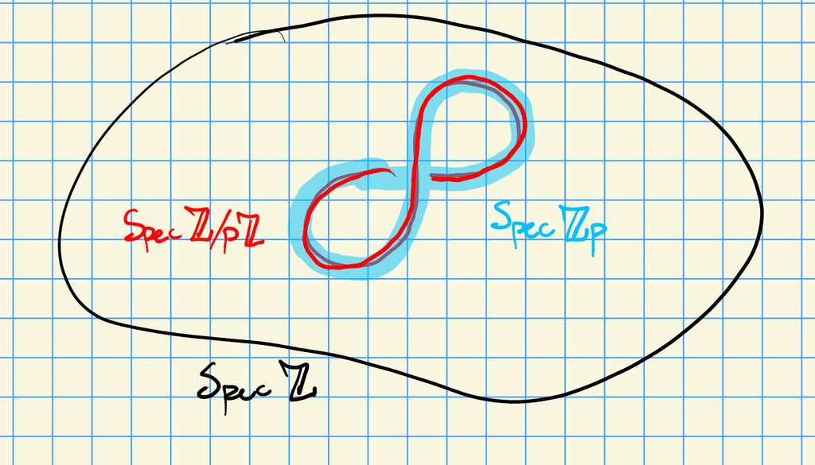

- The 3-dimensional objects: $\operatorname{Spec}R$ for $R = {\mathbb{Z}}, {\mathbb{Z}}{ \left[ { \scriptstyle \frac{1}{p} } \right] }, {\mathbb{Z}} { \left[ \scriptstyle {\sqrt 2} \right] }$, or ${\mathbb{F}}_p(t)$, ${ {\mathbb{Z}}_p }$, or projective smooth curves over ${\mathbb{F}}_p$.
- The 2-dimensional objects: ${ {\mathbb{Q}}_p }, {\mathbb{F}}_p{\left(\left( t \right)\right) }$, or projective smooth curves over $\mkern 1.5mu\overline{\mkern-1.5mu{\mathbb{F}}\mkern-1.5mu}\mkern 1.5mu_p$.

Relating to automorphic forms: for $G={\operatorname{SL}}_2$,

- For ${\mathbb{Z}}$, we study the vector space ${\mathcal{A}}_{\mathbb{Z}}= \left\{{\text{functions on } \dcosetl{G({\mathbb{Z}})}{G({\mathbb{R}})}}\right\}$.
- For ${\mathbb{Z}}{ \left[ { \scriptstyle \frac{1}{p} } \right] }$, we instead look at ${\mathcal{A}}_{{\mathbb{Z}}{ \left[ { \scriptstyle \frac{1}{p} } \right] }}= \left\{{\text{functions on } \dcosetl{G({\mathbb{Z}}{ \left[ { \scriptstyle \frac{1}{p} } \right] })}{ G({\mathbb{R}}) \times G({ {\mathbb{Q}}_p })} }\right\}$.

We would like some association that works similarly:
$$\begin{align*}
{\mathsf{Mfd}}^3 &\to { \mathsf{Vect} }_{/ {k}} \\
M &\mapsto {\mathcal{A}}_M
.\end{align*}$$

A non-example is $M\mapsto H_{\mathrm{sing}}^*(M; {\mathbb{C}})$, which behaves nothing like ${\mathbb{Z}}\mapsto {\mathcal{A}}_{\mathbb{Z}}$. E.g. it has the wrong type of functoriality: the map ${\mathbb{Z}}\to {\mathbb{Z}} { \left[ \scriptstyle {\sqrt 2} \right] }$ is like a branched double cover, but for manifolds there are maps both ways and here it is difficult to find wrong-way maps. Moreover the corresponding spaces of automorphic forms ${\mathcal{A}}_{{\mathbb{Z}}}, {\mathcal{A}}_{{\mathbb{Z}}{ \left[ { \scriptstyle \frac{1}{p} } \right] }}$ differ by far more than just a part coming from ${ {\mathbb{Q}}_p }$.

Note also that $H^*(M \cup N) \cong H^*(M) \oplus H^*(N)$, but for automorphic forms we have ${\mathcal{A}}_{{\mathbb{Z}}\oplus {\mathbb{Z}}} \cong {\mathcal{A}}_{\mathbb{Z}}\otimes{\mathcal{A}}_{\mathbb{Z}}$, where the source is like a degenerate quadratic extension.

A heavily studied piece of the analogy:
$$\begin{align*}
{\operatorname{ {\text{Automorphic forms}} }}\rightleftharpoons{\mathsf{TQFT}}
,\end{align*}
coming from the Kapustin-Witten 2006, where a (4-dimensional) TQFT is a essentially a monoidal functor:
\begin{align*}
{\mathsf{TQFT}}^3 = [({\mathsf{Bord}}^3, {\textstyle\coprod}) \to ({ \mathsf{Vect} }_{/ {k}} , \otimes_k)]
.\end{align*}
.$$

> See [Atiyah TQFT](https://www.math.ru.nl/~mueger/TQFT/At.pdf), section 2.

# 2 Closing: Akshay Venkatesh

Automorphic forms using TFQTs as a metaphor. We’ll consider ${\mathsf{TQFT}}_4 = [({\mathsf{Bord}}^3, {\textstyle\coprod}), ({ \mathsf{Vect} }_{/ {{\mathbb{C}}}} , \otimes_{\mathbb{C}})]$ where ${\mathsf{Bord}}^3$ is the category whose objects are 3-manifolds and morphisms $M\to N$ are 4-manifolds $W$ with ${{\partial}}W = M {\textstyle\coprod}N$. These are meant to extract invariants of 4-manifolds that are amenable to cut-and-paste arguments. The correspondences:

- Manifolds $M \leadsto$ vector spaces $A_M$,
- Bordisms $(M\to N)\leadsto$ linear maps $A_M\to A_N$,
- A 4-manifold $Z$ with boundary $M \leadsto$ a vector $v_Z \in A_M$
- A 4-manifold $Z$ with empty boundary $\leadsto \lambda_Z\in {\mathbb{C}}$
- A decomposition $X$ without boundary into $M{\textstyle\coprod}_Z N \leadsto$ vector $\ell\in A_M, r\in A_M {}^{ \vee }$, where ${\left\langle {\ell},~{r} \right\rangle} = \lambda_Z$.

Fix $G\in{\mathsf{Fin}}{\mathsf{Grp}}$, and a correspondence

- $S^1 \leadsto {\mathbb{C}}[G]^{\mathrm{conj} }$, conjugacy-invariant functions in the group algebra,
- Pants $\leadsto$ multiplication
- $\Sigma_g$ a genus $g$ surface $\leadsto {1\over k!} N$ where $N$ is the number of ways to write $e\in G$ as a product of $g$ commutators.

An informal definition of **extended TQFTs**, in particular ${\mathsf{TQFT}}_4$:

- 4-manifolds $\leadsto {\mathbb{C}}$
- 3-manifolds $\leadsto { \mathsf{Vect} }_{/ {{\mathbb{C}}}}$
- 2-manifolds $\leadsto$ categories enriched over ${ \mathsf{Vect} }_{/ {{\mathbb{C}}}}$

This should yield

- 3-manifolds without boundary $\leadsto A_S$ objects in $\mathsf{C}$
- $X = M{\textstyle\coprod}_Z N \leadsto \mathop{\mathrm{Hom}}(A_M, A_N)$

## 2.1 Automorphic Forms as ${\mathsf{TQFT}}_4$

What should the automorphic form correspondence be in this analogy? Our 3-dimensional objects:

- ${\mathbb{Z}}\leadsto {\mathcal{A}}_{\mathbb{Z}}$ functions on $\dcosetl{G_{\mathbb{Z}}}{G_{\mathbb{R}}}$,
- ${\mathbb{Z}}{ \left[ { \scriptstyle \frac{1}{p} } \right] }\leadsto {\mathcal{A}}_{{\mathbb{Z}}{ \left[ { \scriptstyle \frac{1}{p} } \right] }}$ functions on $\dcosetl{?}{G_{\mathbb{R}}{ {}^{ \scriptscriptstyle\times^{2} } }}$,
- $X_{/ {{\mathbb{F}}_p}}$ a smooth projective curve $\leadsto$ functions on ${\mathsf{Bun}}_G(X)$,
- ${ {\mathbb{Z}}_p }\leadsto$ something more difficult.

The 2-dimensional objects:

- ${ {\mathbb{Q}}_p }\leadsto {\mathsf{Rep}}G({ {\mathbb{Q}}_p })$,
- ${\mathbb{R}}\leadsto {\mathsf{Rep}}G({\mathbb{R}})$,
- $X_{/ {\mkern 1.5mu\overline{\mkern-1.5mu{\mathbb{F}}\mkern-1.5mu}\mkern 1.5mu_p}}$ a smooth projective curve $\leadsto {\mathsf{Sh}}({\mathsf{Bun}}_G(X))$.

Really for a TQFT, we should assign something to objects in the category of its boundary – here e.g. the vector space ${\mathcal{A}}_{{\mathbb{Z}}}$ is an object in ${\mathsf{Rep}}G({ {\mathbb{Q}}_p })$. Idea: functions on ${\mathsf{Bun}}_G$ are hard to deal with, e.g. Hecke operators turn into infinite sums. Make things robust to passing to algebraic closures by passing from functions to sheaves!

Last time: thinking of $\operatorname{Spec}{\mathbb{Z}}$ as a 3-manifold,
$$\begin{align*}
\operatorname{Spec}{\mathbb{Z}}= \operatorname{Spec}{ {\mathbb{Z}}_p }{ \displaystyle\coprod_{\operatorname{Spec}{ {\mathbb{Q}}_p }} } \operatorname{Spec}{\mathbb{Z}}{ \left[ { \scriptstyle \frac{1}{p} } \right] } \approx M^3{ \displaystyle\coprod_{Z^2} }N^3
.\end{align*}
We want the following:
\begin{align*}
\mathop{\mathrm{Hom}}_{G({ {\mathbb{Q}}_p })}({\mathcal{A}}_{{ {\mathbb{Z}}_p }}, {\mathcal{A}}_{{\mathbb{Z}}{ \left[ { \scriptstyle \frac{1}{p} } \right] }}) =_? {\mathcal{A}}_{{\mathbb{Z}}}
.\end{align*}$$

We regard ${\mathcal{A}}_{\mathbb{Z}}$ as elements of ${\mathcal{A}}_{{\mathbb{Z}}{ \left[ { \scriptstyle \frac{1}{p} } \right] }}$ which are also unramified at $p$, and by Frobenius reciprocity this should yield
$$\begin{align*}
{\mathcal{A}}_{\mathbb{Z}}= \mathop{\mathrm{Hom}}_{G({ {\mathbb{Q}}_p })}
\qty{\left\{{
\text{Functions on } \dcosetr{ G({ {\mathbb{Q}}_p })}{G({ {\mathbb{Z}}_p })} , {\mathcal{A}}_{{\mathbb{Z}}{ \left[ { \scriptstyle \frac{1}{p} } \right] }}
}\right\}}
,\end{align*}
which should encode a Hecke algebra at \(p\).$$

What is the Langlands correspondence in this language? What should an “arithmetic TQFT” be?

Let $O$ be a category of arithmetic ring and $A_O$ be a category or vector space, and call an associated $O\to A_O$ an *arithmetic field theory*. Let $X_{/ {{\mathbb{F}}_p}}$ be a smooth projective curve and $G=\operatorname{GL}_n$. The Langlands correspondence here (due to Drinfeld and Lafforgue) yields
$$\begin{align*}
\left\{{\substack{
\text{Cuspidal functions on $n{\hbox{-}}$dimensional} \\
\text{vector bundles on } X
}}\right\}
&\rightleftharpoons
\left\{{\substack{
\text{Functions on $n{\hbox{-}}$dimensional} \\
\text{irreducible Galois reps}
}}\right\}\\
T_x\curvearrowright x &\rightleftharpoons\operatorname{Frob}_x \curvearrowright?
\end{align*}
We regard the LHS \(A\) as “automorphic forms.”$$

This suggests the following viewpoint on the Langlands correspondence: we are only seeing one level, and there is a *second* arithmetic field theory $B^{(G {}^{ \vee })}$ built out of Galois representations of the Langlands dual $G {}^{ \vee }$, so ${\mathbb{Z}}$ yields a vector space and ${ {\mathbb{Q}}_p }$ yields a category, and an equivalence of arithmetic field theories $A^{(G)} \rightleftharpoons B^{(G {}^{ \vee })}$. Often $B$ is a category of coherent sheaves. This should package local, global, and geometric Langlands into a single theory!

The abstract correspondence between automorphic forms and Galois reps isn’t so useful; the real utility comes from matching structures and numerical invariants on both sides, e.g. Fourier coefficients, Rankin-Selberg or doubling integrals, the $\Theta$ correspondence, etc which all match with something on the Galois side (usually an $L{\hbox{-}}$function). This yields a panoply of matching invariants! E.g. for $E/{\mathbb{Q}}$ an elliptic curve,
$$\begin{align*}
L(\operatorname{Sym}^2 E, 1) = \prod_p {p^2 \over (1-1/p) {\sharp}E({\mathbb{F}}_{p^2})} \in \pi\cdot \mathrm{Area}(E_{\mathbb{C}}) {\mathbb{Q}}
,\end{align*}
where the area is of the fundamental parallelogram of \(E\), which is hard to prove without automorphic forms. How can we interpret this in terms of TQFTs?$$

Consider numerical invariants of automorphic forms and Galois reps landing in ${\mathbb{C}}$. Let ${\mathcal{O}}$ be a 3-dimensional ring of integers over $X$.

The numerical invariants of Galois reps should be elements of $B_{\mathcal{O}}^{(G {}^{ \vee })}$, and numerical invariants of automorphic forms should come from $A_{\mathcal{O}}^{(G)}$ where given $P$, one takes $\phi\mapsto {\left\langle {P},~{\phi} \right\rangle}$. To find matching invariants, we want to match elements in $A_{\mathcal{O}}$ to elements in $B_{\mathcal{O}}$. More ambitiously, we can ask for matching *boundary conditions* in $A^{(G)}$ and $B^{(G {}^{ \vee })}$.

A **boundary condition** in ${\mathsf{TQFT}}_4$ is a coherent assignment:

- 3-manifolds $M \leadsto v\in A_M$ a distinguished vector
- 2-manifolds $S \leadsto X_S$ a distinguished object in $A_S$

> See Kasputin’s 2010 ICM address for a nice overview.

Joint work with David Ben-Zvi, Sakellaridis, an informal summary:

- A variety $G{\hbox{-}}$variety gives a boundary condition for both $A^{(G)}$ and $B^{(G {}^{ \vee })}$,
- For suitable choice of $Y$, this recovers familiar invariants of automorphic forms mentioned above,
- On the Galois side this recovers $L{\hbox{-}}$functions,
- There is a proposed specific class of dual pairs $(G, Y) \rightleftharpoons(G {}^{ \vee }, Y {}^{ \vee })$ which give matching/dual invariants. E.g. each periodic integral should have a dual.

For the next generation of number theorists: why are there such similarities between TQFTs and automorphic forms? This is something deep that we barely understand at all.

Extending to 1-dimensional objects: these should be 2-categories which are categorical reps of a loop group.

# 3 Ellen Eischen, Automorphic Forms on Unitary Groups, Talk 1

Overall plan:

- Introduce automorphic forms on unitary groups,
- Techniques to study *algebraic* aspects of $L{\hbox{-}}$functions,
- Using unitary groups as a convenient setting – a large enough class of groups to be interesting, but confined enough to be tractable.

Today:

- Motivations from modular forms,
- Fundamental definitions.

If the previous talk was a “fairy tale,” this will flesh out the “based on a true story” part!

## 3.1 Motivation from modular forms

Consider $\zeta(2k)$ for $k\in {\mathbb{Z}}_{\geq 0}$; known to Euler as
$$\begin{align*}
\zeta(2k) = (-1)^k \pi^{2k} {2^{2k-1} \over (2k-1)!} \qty{-{ {B_{2k}} \over 2k} }
= (-1)^k \pi^{2k} {2^{2k-1} \over (2k-1)!} \zeta(1-2k)
,\end{align*}
where \(B_{2k}\) is the \(2k\)th Bernoulli number, whose exponential generating function is
\begin{align*}
{ze^z\over e^z-1} = \sum_{k\geq 0} B_k {z^k\over k!} \in {\mathbb{Q}}{\left[\left[ z \right]\right] }
.\end{align*}$$

Proving rationality of $\zeta(2k)$ (up to powers $\pi^n$) involves the normalized Eisenstein series
$$\begin{align*}
G_{2k}(q) = \zeta(1-2k) + 2\sum_{k\geq 1} \sigma_{2k-1}(n) q^n, \quad q\mathrel{\vcenter{:}}= e^{2\pi i z}, \quad \sigma_k(n) \mathrel{\vcenter{:}}=\sum_{d\divides n} d^k
,\end{align*}
and one can use similar techniques to prove rationality for$$

- Dedekind zeta functions for $K\in \mathsf{Field}_{/ {{\mathbb{Q}}}}$ totally real:
  $$\begin{align*}
  \zeta_K(s) = \sum_{{\mathfrak{a}}{~\trianglelefteq~}{\mathcal{O}}_K} {1\over N({\mathfrak{a}})^s}, \qquad N(I) \mathrel{\vcenter{:}}=\operatorname{Nm}_{K/{\mathbb{Q}}}(I)
  ,\end{align*}
  where rationality was proved by realizing it as the constant term of a Fourier expansion of an Eisenstein series and studying spaces of modular forms.$$
- $L{\hbox{-}}$functions $L(\chi, s)$ for $\chi$ a **Hecke character** of a totally real field, and their $p{\hbox{-}}$adic analogs.

All of these correspond to **Artin $L{\hbox{-}}$functions** $L(s, \rho)$ for $\rho$ a Galois representation. Dimensions $n=1$ and (partially) $n=2$ are handled class field theory. Can we generally show special values are algebraic? And if so, what do these values mean?

More generally, one can ask about algebraicity or rationality of special values of $L{\hbox{-}}$functions attached to modular forms. Our first tool for constructing such things will be **Rankin-Selberg convolution**. Why care about special values: Kummer used congruences for $\zeta$, checking if $p\divides { \operatorname{cl}} (K)$ is equivalent to checking if $p$ divides numerators of Bernoulli numbers, which can be used to prove special cases of Fermat. Picked up later for Iwasawa theory, controls behavior of towers of towers of cyclotomic extensions in ${\mathsf{G_K}{\hbox{-}}\mathsf{Mod}}$.

Conjectures

- Meanings of $L{\hbox{-}}$function values, e.g. Deligne’s conjecture that they come from **motives**.
- Langlands: connections between Galois reps $\rho$ and automorphic reps.

It might seem like $\operatorname{GL}_n$ for $n\geq 3$ is the next step, but this turns out to be too general! Even ${\operatorname{SL}}_n$ in these ranges is difficult. Instead we’ll move to **unitary groups**, where we’ll have Shimura varieties to work with.

## 3.2 Unitary groups

Fix $K\in {\mathrm{CM}}\mathsf{Field}$, so $K/K^+/{\mathbb{Q}}$ with $K^+/{\mathbb{Q}}$ totally real and $K/K^+$ quadratic imaginary, and $V\in { \mathsf{Vect} }_{/ {K}}$ with a nondegenerate Hermitian pairing ${\left\langle {{-}},~{{-}} \right\rangle}$, which can be extended linearly to $V_R \mathrel{\vcenter{:}}= V\otimes_{K^+} R$ for any $R\in\mathsf{Alg}_{/ {K^+}}$.

The **general unitary group** is the algebraic group $G \mathrel{\vcenter{:}}=\operatorname{GU}(V, {\left\langle {{-}},~{{-}} \right\rangle})$ which is defined for each $R\in \mathsf{Alg}_{/ {K^+}}$ as
$$\begin{align*}
R \mapsto \left\{{g\in \operatorname{GL}_{K_R}(V_R) {~\mathrel{\Big\vert}~}{\left\langle {gv},~{gw} \right\rangle} = \nu {\left\langle {v},~{w} \right\rangle} \text{ for some } \nu\in R}\right\}
.\end{align*}
The unitary group is the subgroup for which \(\nu = 1\) is enforced.$$

If $R={\mathbb{R}}$, choose an ordered basis for $B$ to define the **signature**
$$\begin{align*}
{\left\langle {v},~{w} \right\rangle} = vA { {}^{t}{ (w) } }, \qquad A = {
\begin{bmatrix}
{\one_a} & {0}
\\
{0} & {-\one_b}
\end{bmatrix}
},\qquad
\operatorname{sig}(A) \mathrel{\vcenter{:}}=(a, b)
.\end{align*}$$

For the remainder of today, assume $K^+ = {\mathbb{Q}}$.

## 3.3 Automorphic forms on unitary groups, connections to modular forms

On the modular form side:

On the automorphic side:

1. Replace ${\mathfrak{h}}$ with $G/{\mathcal{K}}_\infty = {\operatorname{U}}_{n, m}({\mathbb{R}})/ {\operatorname{U}}_n{ {}^{ \scriptscriptstyle\times^{2} } }$, a quotient by a compact.
2. Writing $G\mathrel{\vcenter{:}}=\operatorname{GU}(n, m)$ for a form of signature $(n,m)$, replace with $\dcosetl{\Gamma Z(G)}{G}$ where $G\supseteq{\mathcal{K}}_\infty \mathrel{\vcenter{:}}= U(n){ {}^{ \scriptscriptstyle\times^{2} } }$, and analogously $\dcosetl{\Gamma Z(G)}{G({\mathbb{R}})} \to {\mathbb{C}}$.
3. For $G({\mathbb{A}}_f) = {\textstyle\coprod}_i G({\mathbb{R}})^{-1}? {\mathcal{K}}$.

An **automorphic form** on ${\operatorname{U}}_{n, n}$ is a holomorphic function $f\in {\mathfrak{h}}_n\to V$ where $\rho\curvearrowright V$ is a representation of $\operatorname{GL}_n({\mathbb{C}}){ {}^{ \scriptscriptstyle\times^{2} } }$ where
$$\begin{align*}
f(z) = \rho(cz+d, { {}^{t}{ (\mkern 1.5mu\overline{\mkern-1.5muc\mkern-1.5mu}\mkern 1.5mu) } } z + \mkern 1.5mu\overline{\mkern-1.5mud\mkern-1.5mu}\mkern 1.5mu)^{-1}f( \gamma z)\qquad \forall \gamma \in \Gamma = {
\begin{bmatrix}
{a} & {b}
\\
{c} & {d}
\end{bmatrix}
}\in {\operatorname{U}}_{n, n}({\mathcal{O}}_K)
\end{align*}
where
\begin{align*}
\gamma z = (az+b)(cz+d)^{-1}, \qquad {\mathfrak{h}}_n \mathrel{\vcenter{:}}=\left\{{z\in \operatorname{Mat}_n({\mathbb{C}}) {~\mathrel{\Big\vert}~}i({ {}^{t}{ (\mkern 1.5mu\overline{\mkern-1.5muz\mkern-1.5mu}\mkern 1.5mu) } } - z) > 0}\right\}
.\end{align*}$$

One thing we haven’t mentioned yet: modular forms as sections of line bundles over modular curves, so moduli of elliptic curves with level structure, and the generalized setup will be vector bundles over (unitary) Shimura varieties.

# 4 Ellen Eischen, Talk 2

Today: more on automorphic forms, and approaches to studying $L(s, \pi)$ for $\pi$ a cuspidal representation of a unitary group. Note that we’ve been taking the adelic approach, see Wee Tek’s talk for how to define $L{\hbox{-}}$functions in this setting.

Several perspectives on automorphic forms on unitary groups:

- Functions on generalizations of ${\mathfrak{h}}$,
- Functions on $G({\mathbb{R}})$ and $G({\mathbb{A}})$ for $G = {\operatorname{U}}_{a, b}$ a unitary group,

Today: sections of a vector bundle over certain moduli spaces.

> See Shimura’s first paper on Rankin-Selberg convolutions! See also two papers by Siegel’s student that define the generalizations ${\mathfrak{h}}_n$.

## 4.1 Modular Forms

Let ${\mathcal{M}}$ be a modular curve (parameterizing curves with some level structure) and let $\xi\to {\mathcal{M}}$ be the universal elliptic curve. Write $\Omega_{\xi/{\mathcal{M}}}^1$ for the relative differentials, and define
$$\begin{align*}
\omega \mathrel{\vcenter{:}}=\pi_* \Omega^1_{\xi/{\mathcal{M}}}
.\end{align*}
A modular form is section of a tensor power of \(\omega\), i.e. an element of \(H^0({\mathcal{M}}; \omega{ {}^{ \scriptstyle\otimes_{}^{k} } })\).$$

We can regard a modular form as a rule $(E, \omega) \mapsto F(E, \omega)\in {\mathbb{C}}$ that transforms like
$$\begin{align*}
F(E, \lambda \omega) = \lambda^{-k} F(E, \omega) \qquad\forall \lambda\in {\mathbb{C}}^{\times}
.\end{align*}
Equivalently, a rule \(\tilde F\) that maps \(E\) to some \(\omega\in \Omega_{E/{\mathbb{C}}}\), e.g.
\begin{align*}
\tilde F(E) = F(E, \omega)\omega{ {}^{ \scriptstyle\otimes_{}^{k} } }
.\end{align*}$$

Connecting this with last time:
$$\begin{align*}
(E, \omega) \rightleftharpoons\Lambda_{(E, \omega)} \rightleftharpoons{\mathbb{Z}}+ \tau {\mathbb{Z}}\\
F(E, \omega) \longrightarrow\cdots \longrightarrow f_F(\tau)
,\end{align*}
i.e. such a rule can be regarded as a function on lattices.$$

Similarly, automorphic forms arise as global sections of a vector bundle over a unitary Shimura variety ${\mathcal{M}}$ parameterizing abelian varieties with

- A polarization,
- An endomorphism, and
- A level structure.

One can similarly identify
$$\begin{align*}
{\mathcal{M}}({\mathbb{C}}) \cong \dcoset{G({\mathbb{Q}})}{G({\mathbb{A}})}{{\mathcal{K}}\cdot {\mathcal{K}}_\infty}
,\end{align*}
which will be a finite disjoint unions of copies of symmetric spaces (e.g. \({\mathfrak{h}}_n\)) for \({\operatorname{U}}_{a, b}\).$$

Write $\underline{A}$ for an abelian variety with some extra structure, one can then also view an automorphic form as a function
$$\begin{align*}
F(\underline{A}, \ell) = \rho(tg)^{-1}F(\underline{A},\ell) \qquad \forall G\in \operatorname{GL}_a \times \operatorname{GL}_b
,\end{align*}
where \(\ell = (\ell_+, \ell_-)\) is an ordered basis for \(\Omega_{A/{\mathbb{C}}}\) that decomposes according to the signature.$$

Let ${\mathcal{A}}\xrightarrow{\pi} {\mathcal{M}}$ be the universal family and define the sheaf $\omega \mathrel{\vcenter{:}}=\pi_* \Omega_{{\mathcal{A}}/{\mathcal{M}}}$; one can then build a sheaf of automorphic forms $\omega^p$ in much the same way. This reformulates the notion of an automorphic form in terms of lattices and functions on symmetric spaces like ${\mathfrak{h}}_n$.

## 4.2 ?

Goal for today: introduce an approach to studying certain $L{\hbox{-}}$functions using the *doubling method*. Note that the example of looking at the constant term of an Eisenstein series from yesterday turns out to be deceptively simple, hence a different approach today.

Let - $f(q) = \sum_{k\geq 1} a_kq^k$ be a weight $k$ cusp form and - $g(q) = \sum_{k\geq 0} b_kq^k$ be a weight $\ell$ modular form,

where $a_k, b_k \in { \mkern 1.5mu\overline{\mkern-1.5mu \mathbb{Q} \mkern-1.5mu}\mkern 1.5mu }$. The **Rankin-Selberg product** is
$$\begin{align*}
D(s,f,g) = \sum_{n\geq 1} a_n b_n n^{-s}
.\end{align*}$$

Shimura proved that
$$\begin{align*}
{ D(m,f,g) \over {\left\langle {f},~{f} \right\rangle}_{{\mathrm{Pet}}} } \in \pi^k { \mkern 1.5mu\overline{\mkern-1.5mu \mathbb{Q} \mkern-1.5mu}\mkern 1.5mu }\qquad \text{for } \ell < k,\, {k+\ell-2\over 2} < m < k
.\end{align*}$$

This prove relies on the realization
$$\begin{align*}
D(k-1-r, f, g) = c\pi^k {\left\langle {\tilde f},~{\, g\delta_{ \lambda}^{(r)} E } \right\rangle}_{{\mathrm{Pet}}}
,\end{align*}
where$$

- $E$ is an Eisenstein series of weight $\lambda = k-\ell - 2r$
- $\delta$ is a Maass-Shimura differential operator that raises weights by $2r$,
- $\tilde f$ is $f$ with conjugate Fourier coefficients, so $\tilde f(q) \mathrel{\vcenter{:}}=\sum_{k\geq 0} \mkern 1.5mu\overline{\mkern-1.5mua_k\mkern-1.5mu}\mkern 1.5mu q^k$
- ${\left\langle {f},~{g} \right\rangle}_{\mathrm{Pet}}$ is the Petersson pairing: for $F$ a fundamental domain
  $$\begin{align*}
  {\left\langle {f},~{g} \right\rangle}_{\mathrm{Pet}}\mathrel{\vcenter{:}}=\int_F \mkern 1.5mu\overline{\mkern-1.5muf\mkern-1.5mu}\mkern 1.5mu(z) g(z)\, y^{l-2}\,dx\,dy
  .\end{align*}$$

Note that the weight-raising operator doesn’t preserve holomorphicity, which can be bad for algebraicity results, but it turns out that the result is “almost holomorphic.”

## 4.3 Proving Algebraicity: A Recipe

A general strategy:

- Find a Petersson-style pairing of automorphic forms, e.g. integrating against an Eisenstein series, which looks like an $L{\hbox{-}}$function:
  - Factors into an Euler product
  - Has a functional equation
  - Can be meromorphically continued to ${\mathbb{C}}$
- Prove appropriate rationality results for $E$, e.g. the higher order Fourier coefficients are rational, or $E$ transforms nicely under a differential operator. Fourier coefficients are almost always important in this step.
- Express a familiar automorphic $L{\hbox{-}}$function in terms of this pairing.

Note that each step is highly nontrivial, and in some contexts, some steps haven’t even been completed yet. The third step often involves working one place at a time. Even having all three may not be enough, sometimes the results one gets aren’t amenable to algebraic/geometric study and are instead only good for analytic purposes.

## 4.4 Doubling

Setup:

- $K\in \mathsf{Field}_{/ {{\mathbb{Q}}}}$ a quadratic extension
- $V\in { \mathsf{Vect} }_{/ {K}} ^{\dim = n}$ with a nondegenerate Hermitian pairing ${\left\langle {{-}},~{{-}} \right\rangle}_V$
- $G = {\operatorname{U}}(V, {\left\langle {{-}},~{{-}} \right\rangle}_V)$
- $W = V{ {}^{ \scriptscriptstyle\oplus^{2} } }$ with the induced Hermitian pairing
  $$\begin{align*}
  {\left\langle {(u, v)},~{(u', v')} \right\rangle}_W \mathrel{\vcenter{:}}={\left\langle {u},~{u'} \right\rangle}_V - {\left\langle {v},~{v'} \right\rangle}_V
  .\end{align*}$$
- A *doubled* group $H \mathrel{\vcenter{:}}={\operatorname{U}}(W, {\left\langle {{-}},~{{-}} \right\rangle}_W)$
- An embedding
  $$\begin{align*}
  {\operatorname{U}}(V, {\left\langle {{-}},~{{-}} \right\rangle}) \times
  {\operatorname{U}}(V, -1\cdot {\left\langle {{-}},~{{-}} \right\rangle})
  \hookrightarrow H
  ,\end{align*}
  which in terms of signatures is \(\operatorname{sig}(a, b) \times \operatorname{sig}(b, a) \to \operatorname{sig}(a+b, a+b)$$

Next time: we’ll introduce the doubling integral after pairing with an Eisenstein series.

# 5 Ellen Eischen, Talk 3

Some references on doubling:

- PIatestski-Shapiro, Rallis, $L{\hbox{-}}$functions for classical groups
- Harris, Shimura varieties for unitary groups and the doubling method
- Garrot, Pullbacks of Eisenstein series

## 5.1 Eisenstein Series

We’ll continue with the previous setup. Let $P \leq H$ be parabolic preserving $V^\Delta \mathrel{\vcenter{:}}=\left\{{(v,v) {~\mathrel{\Big\vert}~}v\in V}\right\}$. We get a decomposition $W = V^\Delta \oplus V_\Delta$ where $V_\Delta = \left\{{(v, -v) {~\mathrel{\Big\vert}~}v\in V}\right\}$. Then
$$\begin{align*}
P = \left\{{ {
\begin{bmatrix}
{A} & {*}
\\
{0} & {{ {}^{t}{ (\mkern 1.5mu\overline{\mkern-1.5muA\mkern-1.5mu}\mkern 1.5mu^{-1}) } }}
\end{bmatrix}
} {~\mathrel{\Big\vert}~}A\in \operatorname{GL}_n}\right\}
.\end{align*}$$

Given a Hecke character
$$\begin{align*}
\chi: \dcosetl{K^{\times}}{{\mathbb{A}}_K^{\times}}\to {\mathbb{C}}
,\end{align*}
view this as a character of \(P\) via
\begin{align*}
P\to \operatorname{GL}_n \xrightarrow{\operatorname{det}} {\mathbb{A}}_K^{\times}\to {\mathbb{C}}\\
{
\begin{bmatrix}
{A} & {*}
\\
{0} & {{ {}^{t}{ (\mkern 1.5mu\overline{\mkern-1.5muA\mkern-1.5mu}\mkern 1.5mu^{-1}) } }}
\end{bmatrix}
} \mapsto A\mapsto \operatorname{det}(A) \xrightarrow{\chi} \chi(\operatorname{det}(A))
.\end{align*}$$

For $s\in {\mathbb{C}}$, let
$$\begin{align*}
f_{S, \chi} = \operatorname{Ind}_{P({\mathbb{A}})}^{H({\mathbb{A}})} (\chi \cdot {\left\lvert {{-}} \right\rvert}^{-s} ) = \left\{{f: H({\mathbb{A}})\to {\mathbb{C}}{~\mathrel{\Big\vert}~}f(ph) = \chi(p) {\left\lvert {p} \right\rvert}^{-s} f(h)}\right\}
.\end{align*}
Define the Siegel Eisenstein series for \(g\in H\) by
\begin{align*}
E_{F_s, \chi}(g) = \sum_{\gamma \in \dcosetl{ P({\mathbb{Q}}) }{ H({\mathbb{Q}}) } } f_{s, \chi}(\gamma g)
.\end{align*}$$

## 5.2 Doubling Integral

Setup:

- $\pi$ a cuspidal automorphic representation of $G$
- $\tilde \pi$ the contragradient (dual) representation of $\pi$
- $\phi\in \pi$
- $\tilde\phi\in \tilde\pi$

Define a zeta integral
$$\begin{align*}
Z(\phi, \tilde\phi, f_{s, \chi}) \mathrel{\vcenter{:}}=\int_{ \dcosetl{(G\times G)({\mathbb{Q}})}{(G\times G)({\mathbb{A}})} }
E_{f_{s, \chi}} (g_1, g_2) \phi(g_1) \tilde \phi(g_2) \chi^{-1}(\operatorname{det}g_2) \,dg _1 \,dg _2
,\end{align*}
which is against an appropriately normalized Haar measure.$$

Most analytic properties of $E$ will carry over to $Z$, e.g. the functional equation and meromorphic continuation – this is a common theme! In the case of $G = \operatorname{GU}_1$ or $\operatorname{GU}_n$ a definite unitary group, one can express $Z$ as a *finite* sum.

$$\begin{align*}
Z(\phi, \tilde\phi, f_{s, \chi}) = \int_{G({\mathbb{A}})} f_{s, \chi}((g, 1)) {\left\langle {\pi(g) \phi},~{\tilde\phi} \right\rangle} \,dg , \qquad {\left\langle {\phi},~{\tilde\phi} \right\rangle} = \int_{\dcosetl{G({\mathbb{Q}})}{G({\mathbb{A}})}} \phi(g)\tilde\phi(g) \,dg
,\end{align*}
where this pairing is \(G{\hbox{-}}\)invariant which is unique up to a constant multiple.$$

If there is a restricted tensor product representation
$$\begin{align*}
\pi = \bigotimes^{\operatorname{res}}_v \pi_v, \qquad
\tilde \pi = \bigotimes^{\operatorname{res}}_v \tilde \pi_v,
\end{align*}
where \(\operatorname{Ind}(\chi{\left\lvert {{-}} \right\rvert}^v)= \bigotimes O_v\) with$$

- $\phi = \bigotimes^{\operatorname{res}}_v \phi_v$,
- $\tilde \phi = \bigotimes^{\operatorname{res}}_v \tilde \phi_v$,
- $f_{s, \chi} = \bigotimes^{\operatorname{res}}_v f_v$,

then there is an Euler product decomposition
$$\begin{align*}
Z(\phi,\tilde\phi, f_{s,\chi}) = \prod_v Z_v(\phi_v, \tilde\phi_v, f_v)
\end{align*}
where
\begin{align*}
Z_v(\phi_v, \tilde\phi_v, f_v) \mathrel{\vcenter{:}}=\int_{G({\mathbb{Q}}_v)} f_v((g, 1)) {\left\langle {\pi_v(g) \phi_v },~{ \tilde\phi_v} \right\rangle} \,dg
.\end{align*}$$

By the uniqueness of the invariant pairing, there must exist a decomposition
$$\begin{align*}
{\left\langle {\phi},~{\tilde\phi} \right\rangle} = \prod_v
{\left\langle {\phi_v},~{\tilde\phi_v} \right\rangle}
.\end{align*}$$

Shimura computed coefficients in many cases.

Outline proof of the theorem: we’ll analyze the orbits of $G\times G\curvearrowright X\mathrel{\vcenter{:}}=\dcosetl{P}{H}$. Setup:

- Fix $X\mathrel{\vcenter{:}}=\dcosetl{P}{H}$ and write $\gamma\in X$, identifying it with its coset $H\gamma$.
- For each $\gamma\in X$, write $[G\times G]^\gamma \mathrel{\vcenter{:}}={\operatorname{Stab}}_{G\times G}(\gamma)$.
- Write $[\gamma]$ for the orbit of $P\gamma$ under the $G\times G$ action.

Idea: write $E$ as a sum and rearrange, then reduce to a known computation. Reexpress it as
$$\begin{align*}
E_{f, \chi} (h)
&=
\sum_{\scriptscriptstyle [\gamma] \in \dcoset{P({\mathbb{Q}})} {H({\mathbb{Q}})} {(G\times G)({\mathbb{Q}})} }
\qty{ \sum_{ \scriptscriptstyle \dcosetl{(G\times G)({\mathbb{Q}})} {(G\times G)({\mathbb{Q}})} } f_{s, \chi}( \gamma h)} \\
&=
\sum_{\scriptscriptstyle [\gamma] \in \dcoset{P({\mathbb{Q}})} {H({\mathbb{Q}})} {(G\times G)({\mathbb{Q}})} }
\qty{ \sum_{ \scriptscriptstyle \dcosetl{(G\times G)({\mathbb{Q}})} {(G\times G)({\mathbb{Q}})} }
\int_{ \scriptscriptstyle \dcosetl{(G\times G)({\mathbb{Q}})} {[G\times G]({\mathbb{A}})} } f_{s, \chi}((g, h)) \phi(g) \tilde\phi(h) \chi^{-1}\operatorname{det}(h) \,dg \,dh }\\
&\mathrel{\vcenter{:}}=
\sum_{\scriptscriptstyle [\gamma] \in \dcoset{P({\mathbb{Q}})} {H({\mathbb{Q}})} {(G\times G)({\mathbb{Q}})} } I(\gamma)
,\end{align*}
where
\begin{align*}
I(\gamma) \mathrel{\vcenter{:}}=
\int_{\dcosetl{[G\times G]^\gamma ({\mathbb{Q}})} {[G\times G]({\mathbb{A}})} } f_{s, \chi}(\gamma(g, h)) \phi(g)\tilde\phi(g) \chi^{-1}\operatorname{det}(g)\,dg \,dh
.\end{align*}$$

We’ll have to analysis the $\gamma = 1$ and $\gamma\neq 1$ cases separately, they’re quite different:

- For $\gamma = 1$, $I(\gamma)$ will be the RHS in the theorem statement.
- For $\gamma\neq 1$, $I(\gamma) = 0$.

Rewrite the stabilizer in a more convenient way:
$$\begin{align*}
[G\times G]^{\gamma}
&= \left\{{(g,h) \in G\times G{~\mathrel{\Big\vert}~}P\gamma(g, h) = P\gamma}\right\} \\
&= \left\{{(g, h)\in G\times G{~\mathrel{\Big\vert}~}\gamma(g, h)\gamma^{-1}\in P}\right\}
,\end{align*}
so
\begin{align*}
[G\times G]^1 = P \cap(G\times G) = \left\{{(g,g){~\mathrel{\Big\vert}~}g\in G}\right\} \mathrel{\vcenter{:}}= G^\Delta
.\end{align*}
Thus
\begin{align*}
f_{s, \chi}(1\cdot(g, h))
&= f_{s, \chi}(g, h) \\
&= f_{s, \chi}((h,h) \cdot (h^{-1}g, 1)) \\
&= \chi(\operatorname{det}h) f_{s,\chi}(h^{-1}g, 1)
\end{align*}
and
\begin{align*}
I(1) =
\int_{\dcosetl{ G^\Delta({\mathbb{Q}}) } {(G\times G)({\mathbb{A}})} } f_{s, \chi}(h^{-1}g, 1) \phi(g)\tilde\phi(g) \,dg \,dh
.\end{align*}
We have an identification
\begin{align*}
G\times G &\rightleftharpoons G^\Delta \times(G\times 1) \rightleftharpoons G\times G \\
(g,h) &\rightleftharpoons(h,h)\cdot(h^{-1}g, 1) \rightleftharpoons(h,h^{-1}g) \mathrel{\vcenter{:}}=(g,g_1)
,\end{align*}
which we can use to write
\begin{align*}
I(1)
&= \int_{G({\mathbb{A}})} \int_{\dcosetl{G({\mathbb{Q}})} {G({\mathbb{A}})} } f_{s,\chi}(g_1, 1) \pi(g_1) \pi(h) \tilde\phi(h)\,dh \,dg _1 \\
&= \int_{G({\mathbb{A}})} f_{s, \chi}(g_1, 1) {\left\langle {\pi(g_1) \pi},~{\tilde\phi} \right\rangle} \,dg _1
.\end{align*}$$

All other orbits $[\gamma]\neq [1]$ decompose to products including terms of the form
$$\begin{align*}
\int_{\dcosetl{N_i({\mathbb{Q}})} {N_i({\mathbb{A}})} } \phi_i(n\cdot g)\,dn
\end{align*}
for \(i=1,2\), \(\phi_1 = \phi, \phi_2 = \tilde \phi\) and \(N_i\) unipotent radicals of a parabolic subgroup of \(G\) which is nontrivial for at least on term – however, these are cuspidal, so such integrals vanish (essentially by definition), making the entire thing vanish.$$

This falls into step 1 of the overall strategy – we found a pairing. So the next question is step 2: can we choose $f_{s, \chi}, \phi,\tilde\phi$ so that we nice multiples of Langlands $L{\hbox{-}}$functions $L(s,\pi,\chi)$? This will rely on reducing to computations to local integrals that were computed by Godement and Jacquet for $\operatorname{GL}_n$.

Next: pulling back automorphic forms to smaller groups, what does this look like for $n=1$?

# 6 Ellen Eischen, Talk 4: Revisiting the Doubling Method for $n=1$

## 6.1 Reducing to Finite Sums

Goal: see what happens if we do the doubling method in the following setup. Let

- $n=1$
- $K\in \mathsf{Field}_{/ {{\mathbb{Q}}}}$ be an imaginary quadratic field
- $V\in { \mathsf{Vect} }^{\dim = 1}_{/ {K}}$
- $W = V{ {}^{ \scriptscriptstyle\oplus^{2} } }$
- $G\mathrel{\vcenter{:}}={\operatorname{U}}(V, {\left\langle {{-}},~{{-}} \right\rangle}_V) \cong {\operatorname{U}}_1 = \left\{{g\in \operatorname{GL}_2 {~\mathrel{\Big\vert}~}g\mkern 1.5mu\overline{\mkern-1.5mug\mkern-1.5mu}\mkern 1.5mu = 1}\right\}$. Note that $G \subseteq \operatorname{GU}(V, {\left\langle {{-}},~{{-}} \right\rangle}_V)\cong \operatorname{GU}_1 \cong \operatorname{GL}_1$
- $H\mathrel{\vcenter{:}}={\operatorname{U}}(W, {\left\langle {{-}},~{{-}} \right\rangle}_V) \cong {\operatorname{U}}_{1, 1}$. Note that $H \subseteq \operatorname{GU}(W, {\left\langle {{-}},~{{-}} \right\rangle}_V)\cong \operatorname{GU}_{1, 1}$

Spoiler: we’ll get an expression for the $L{\hbox{-}}$function $L(s, \chi)$ for a Hecke character $\chi: \dcosetl{K^{\times}}{{\mathbb{A}}_K^{\times}} \to CC^{\times}$ as a finite sum of values $E_\chi(A) \chi(A)$ for some elliptic curves $A$ with CM by ${\mathcal{O}}_K$, and we’ll obtain an algebraicity result.

Note that
$$\begin{align*}
\operatorname{GU}_{1, 1} \cong \dcosetr{\operatorname{GL}_2\times \mathop{\mathrm{Res}}_{K/{\mathbb{Q}}} {\mathbb{G}}_m }{{\mathbb{G}}_m}
,\end{align*}
and the associated symmetric space consists of copies of the upper half plane \({\mathfrak{h}}_1\). The associated modular form is a modular form, possibly with mild additional conditions on each component.$$

Reminder of the doubling method: we had an integral
$$\begin{align*}
Z(s,\chi,\phi,\tilde\phi) = \int_{\dcosetl{G{ {}^{ \scriptscriptstyle\times^{2} } } ({\mathbb{Q}})} {{\mathbb{G}}{ {}^{ \scriptscriptstyle\times^{2} } }({\mathbb{A}})} } E_{f_S, \chi}(g, h) \phi(g) \tilde \phi(h) \chi^{-1}(\operatorname{det}h) \, dg\, dh
.\end{align*}$$

Some properties:

- $Z$ is an automorphic form on $\operatorname{GU}_1 = \operatorname{GL}_1$, and thus a Hecke character.
- If one chooses $\phi=\chi^{-1}$ so $\phi^{-1}= \chi$ (plus some compatibility conditions), $Z$ collapses to a finite sum:
  $$\begin{align*}
  Z(s,\chi,\phi\tilde\phi) = \sum_{\scriptscriptstyle \dcoset{ G{ {}^{ \scriptscriptstyle\times^{2} } } ({\mathbb{Q}}) } { G{ {}^{ \scriptscriptstyle\times^{2} } } ({\mathbb{A}})} { {\mathcal{K}}}} E_{S,\chi}(g,h)\chi^{-1}(g)
  .\end{align*}$$

There is a diagram:

[figure not shown]

> Link to Diagram

Moreover there is an embedding:

[figure not shown]

> Link to Diagram

These induce embeddings of corresponding Shimura varieties:

- ${\mathcal{M}}_{G({\operatorname{U}}_1{ {}^{ \scriptscriptstyle\times^{2} } })} \to {\mathcal{M}}_{\operatorname{GU}_1{ {}^{ \scriptscriptstyle\times^{2} } }}$ which classifies produces $A_1\times A_2$ 1-dimensional AVs with PEL structures, so elliptic curves with CM by ${\mathcal{O}}_K$,
- ${\mathcal{M}}_{G({\operatorname{U}}_1{ {}^{ \scriptscriptstyle\times^{2} } })} \to {\mathcal{M}}_{\operatorname{GU}_{1, 1}}$ which classifies *certain* 2-dimensional AVs with PEL structures.

Recall that the adelic points of our quotients are ${\mathbb{C}}{\hbox{-}}$points of unitary Shimura varieties, and ${\mathcal{M}}_{\operatorname{GU}_{1,1}}({\mathbb{C}}) = {\textstyle\coprod}\dcosetl{\Gamma_K}{{\mathfrak{h}}_1}$ where we mod out by some level. Any $z\in {\mathfrak{h}}= {\mathfrak{h}}_1$ corresponds to some ${\mathbb{C}}{ {}^{ \scriptscriptstyle\times^{2} } }/\left\langle{(z\mkern 1.5mu\overline{\mkern-1.5mua\mkern-1.5mu}\mkern 1.5mu + \mkern 1.5mu\overline{\mkern-1.5mub\mkern-1.5mu}\mkern 1.5mu, za + b)}\right\rangle$ where $a,b$ are in some ${\mathcal{O}}_K$ lattice. Note the similarity to ${\mathbb{C}}/\left\langle{{\mathbb{Z}}+ \tau {\mathbb{Z}}}\right\rangle$ for elliptic curves.

An upshot is that there are three special things in this case:

- Integral is a finite sum,
- There are only characters,
- We’re evaluating at special points!

Let $Z(s, \chi) \mathrel{\vcenter{:}}= Z(s, \chi, \phi,\tilde\phi)$. We can choose $f_{S,\chi}$ such that \begin{align*} Z(s,\chi) = c L(s, \chi) \end{align*} for $c$ a scalar, i.e. they differ by a multiple. This expresses $L(s, \chi)$ as a finite sum of values of $E(s,\chi) \cdot \chi({-})$ for $E$ an automorphic form on ${\operatorname{U}}_{1, 1}$, so a special kind of modular form. There is a variant of *Damerell’s formula*, which expresses $L(s, \chi)$ as such a finite sum where $E$ is an Eisenstein series in a space of Hilbert modular forms.

## 6.2 Rationality Properties for Eisenstein Series

We can obtain an Eisenstein series on ${\mathfrak{h}}= {\mathfrak{h}}_1$ of the form
$$\begin{align*}
\sum_{(c,d)\in \Lambda} {\chi(d) \over (cz+d)^k (cz+d)^s}
\end{align*}
where \(\Lambda\) is an appropriate \({\mathcal{O}}_K\) lattice, and for certain characters will converge for \(\Re(s) + k > 2 = 2n\). This will have rational Fourier coefficients, and is holomorphic for \(s=0\). As in the case of modular forms, there is a \(q{\hbox{-}}\)expansion (or more generally in other signatures, a Fourier-Jacobi expansion) principle:$$

Automorphic forms on ${\operatorname{U}}_{n,n}$ are determined by their $q{\hbox{-}}$expansions.

In particular, if the coefficients of the $q{\hbox{-}}$expansion are contained in $R$, then $f$ is in fact defined over $R$. Kai-Wen Lan proved a more general version of this principle for ${\operatorname{U}}_{a,b}$ with any signature, and showed that algebraic $q{\hbox{-}}$expansions and analytic (i.e. Fourier) expansions agree.

So things look good for $s=0$!

What about $s\neq 0$, i.e. when the Eisenstein series is not holomorphic?

We use Mass-Shimura differential operators $\delta^{(r)}_K$ to relate $E$ at $s\neq 0$ to $E$ at $s=0$, where here $\delta$ raises weights by $2r$. For $F$ a modular form defined over ${ \mkern 1.5mu\overline{\mkern-1.5mu \mathbb{Q} \mkern-1.5mu}\mkern 1.5mu }$, Shimura proved the following:
$$\begin{align*}
{ (\delta_k^{(r)} F)(A) \over \Omega^{k+2r} } \in { \mkern 1.5mu\overline{\mkern-1.5mu \mathbb{Q} \mkern-1.5mu}\mkern 1.5mu }
\end{align*}
for each CM point \(A\). These operators have incarnations in \({\operatorname{U}}_{n, m}\) and there are analogous algebraicity results. In fact,
\begin{align*}
E(z, -r, \chi) = c (-4\pi y)^r \delta_k^{(r)} E(z, 0,\chi)
.\end{align*}
where \(c\) is a nice rational factor. Combining these results yields
\begin{align*}
{L(r, \chi) \over \Omega^{k+2r}}\in {\mathbb{Q}}
.\end{align*}$$

A word about this operator:
$$\begin{align*}
\delta_k f = {1\over 2\pi i} \qty{{k\over 2iy} + {\frac{\partial }{\partial z}\,} } f = {1\over 2\pi i}y^{-k} {\frac{\partial }{\partial z}\,} (y^k f), \qquad \delta_k^{(r)} = \delta_k \circ \delta_k \circ \cdots \circ \delta_k
.\end{align*}
Katz’s idea: reexpress this operator geometrically over a moduli space of elliptic curves, or more generally AVs, in terms of the Gauss-Manin connection and the Kodaira morphism, and a splitting
\begin{align*}
H^1_{\mathrm{dR}} = \omega \oplus H^{0, 1}
\end{align*}
which preserves algebraicity at CM points.$$

# 7 Wee Teck Gan: Automorphic forms and the theta correspondence (Talk 1)

Goal: reformulating the Ramanujan-Petersson conjecture in terms of representation theory.

## 7.1 The Ramanujan-Petersson conjecture

Let $f: {\mathfrak{h}}\to {\mathbb{C}}$ be a holomorphic cusp form of weight $k$ and level 1. Suppose $f$ is an eigenvector for the Hecke operator $T_p$, then $f$ has a Fourier expansion
$$\begin{align*}
f(z) = \sum_{k\geq 1} a_k(f) q^n, \qquad q\mathrel{\vcenter{:}}= e^{2\pi i z}
,\end{align*}
which can be normalized so that \(a_1(f) = 1\). The remaining coefficients are then the Hecke eigenvalues, so
\begin{align*}
T_p f = a_p(f) f
.\end{align*}$$

$$\begin{align*}
{\left\lvert {a_p(f) } \right\rvert} \leq 2p^{k-1\over 2}
.\end{align*}
This was proved by Deligne as a consequence of the Weil conjectures. There is an analog for Maass forms, which involves the hyperbolic Laplacian, which similarly bounds Fourier coefficients.$$

Error terms come from the cusp forms here. There is a bridge that takes holomorphic modular forms and Maass forms to the world of automorphic forms.

Setup: let $k\in \mathsf{Field}_{/ {{\mathbb{Q}}}} , v \in {\operatorname{Places}}(K)$ so that $k_v\in\mathsf{Loc}\mathsf{Field}$. Define the adeles as ${\mathbb{A}}\mathrel{\vcenter{:}}=\prod^{\operatorname{res}}k_v$ which admits a diagonal embedding $k\hookrightarrow{\mathbb{A}}$ with $\dcosetl{k}{{\mathbb{A}}}$ compact. Let $G\in{\mathsf{Alg}}{\mathsf{Grp}}_{/ {k}}$ be reductive, e.g. ${\operatorname{SL}}_n, {\operatorname{U}}_n$, we then similarly have
$$\begin{align*}
G(k) \hookrightarrow G({\mathbb{A}}) = \prod^{\operatorname{res}}_v G(k_v)
\end{align*}
with \(\left\{{k_v}\right\}\) an open compact subgroup. Write \([G] = \dcosetl{G(k)}{G({\mathbb{A}})}\), and note the there is a right action \([G] \curvearrowleft G({\mathbb{A}})\).$$

## 7.2 Automorphic Reps

An **automorphic form** on $G$ is a function $f: [G]\to {\mathbb{C}}$ satisfying

- Regularity conditions: e.g. at worst polynomial growth $f\sim z^k$, smoothness, and derivatives $f^{(n)}\sim z^k$ for the same exponent.
- Finiteness conditions: $K{\hbox{-}}$finiteness for $K = \prod_v k_v$, or more generally $Z({\mathfrak{g}}){\hbox{-}}$finiteness.

Write ${\mathcal{A}}(G)$ for the vector space of automorphic forms on $G$. Note that this carries at left $G({\mathbb{A}})$ action:
$$\begin{align*}
(g_0 . f)(g) = f(g g_0)
.\end{align*}$$

The finiteness condition will guarantee that $f$ will come from the kernel of a differential operator, e.g. the CR equations for holomorphy. Requiring $K{\hbox{-}}$finiteness only gives an action on finite adeles.

An **automorphic representation** is an irreducible representation of ${\mathcal{A}}(A)$.

## 7.3 Cusp Forms

A form $f\in {\mathcal{A}}(G)$ is **cuspidal** iff for all parabolic subgroups $P$ with $P=MN$, the constant term of $f$ along $N$ is zero, where the constant term is defined as
$$\begin{align*}
f_N(g) = \int_{[N]} = f(ng) \,dn
.\end{align*}
This yields a subspace of cusp forms \({\mathcal{A}}_{ \mathrm{cusp} }(G) \leq {\mathcal{A}}(G)\) which is stable under the \(G({\mathbb{A}})\) action.$$

One can take a character $\psi: [N]\to {\mathbb{C}}^{\times}$, then there is a $(N, \psi){\hbox{-}}$Fourier coefficient of $f$:
$$\begin{align*}
f_{N, \psi}(g) = \int_{[N]} \mkern 1.5mu\overline{\mkern-1.5mu\psi(n)\mkern-1.5mu}\mkern 1.5mu \cdot f(ng) \,dn
.\end{align*}$$

Uniform moderate growth and being cuspidal imply that $f\in {\mathcal{A}}_{ \mathrm{cusp} }(G)$ rapidly decays at $\infty$, i.e. faster than $1/p$ for any polynomial, so that $f\in L^2$:
$$\begin{align*}
\int_{[G]} {\left\lvert {f} \right\rvert}^2 < \infty
.\end{align*}
So define the Hilbert space of square-integrable automorphic forms
\begin{align*}
{\mathcal{A}}_2(G) \mathrel{\vcenter{:}}=\left\{{f\in {\mathcal{A}}(G) {~\mathrel{\Big\vert}~}{\left\lVert {f} \right\rVert}_{L^2}<\infty }\right\}
.\end{align*}
There is a containment
\begin{align*}
{\mathcal{A}}_{ \mathrm{cusp} }(G) \subseteq {\mathcal{A}}_2(G) \subseteq {\mathcal{A}}(G)
,\end{align*}$$

where there are a decomposition into irreducible reps

- ${\mathcal{A}}_{ \mathrm{cusp} }(G) = \bigoplus_\pi m(\pi) \pi$ for some cuspidal multiplicities $m$,
- ${\mathcal{A}}_2(G) = \bigoplus_\pi m(\pi)\pi$ for some $L^2$ multiplicities $m$.

A main question for automorphic representations: for which $\pi$ is $m(\pi) > 0$? I.e. which representations occur as cuspidal or $L^2$ reps? Moreover, what do all of the irreducible reps of $G({\mathbb{A}})$ look like?

Recall that since $G({\mathbb{A}}) = \prod^{\operatorname{res}}_v G(k_v)$, we expect a representation $\pi$ of $G({\mathbb{A}})$ to break up as $\pi = \bigotimes^{\operatorname{res}}_v \pi _v$ with

- $\pi_v\in {\mathsf{Irr}}(G(k_v))$,
- $\pi_v^{k_v} \neq 0$ for almost all $v$, so $k_v$ is **unramified** or **spherical**.

## 7.4 Unramified Reps

There is a containment $G_v \supseteq K_v$ where $G_v$ is unramified, i.e. quasi-split (so has a Borel) and split by an unramified extension of $k_v$, and $K_v$ is a **hyper-special** subgroup, which is a maximal compact. This yields $G_v \supseteq B_v\supseteq T_v N_v$, and there is a bijection
$$\begin{align*}
{\mathsf{Irr}}{\mathsf{Rep}}(G_v)(K_v{\hbox{-}}\text{unramified}) &\rightleftharpoons
\left\{{\text{Unramified characters of }T_v}\right\}/W \\
I(\chi) = \operatorname{Ind}_{B_v}^{G_v} \chi &\mapsfrom \chi
,\end{align*}
where we mod out by a Weyl group action \(W\). Note that \(I(\chi)\) is the unique unramified subquotient.$$

There is a further correspondence
$$\begin{align*}
\left\{{\text{Unramified characters of }T_v}\right\}/W \\
&\underset{ {\text{Langlands}} }{\rightleftharpoons}
\left\{{\text{Semisimple conjugacy classes in } G {}^{ \vee }({\mathbb{C}})}\right\} \\
\chi &\mapsto S_\chi
,\end{align*}
so there is some semisimple conjugacy class associated to characters \(\chi\).$$

Thus for $\pi\in {\mathcal{A}}_{ \mathrm{cusp} }(G)$ with $\pi = \bigotimes^{\operatorname{res}}_v \pi_v$, one gets a collection $\left\{{S_{\pi_v} {~\mathrel{\Big\vert}~}v\not\in S}\right\} \subseteq G {}^{ \vee }$. For $R: G {}^{ \vee }\to \operatorname{GL}_N({\mathbb{C}})$, we can form an $L{\hbox{-}}$function
$$\begin{align*}
L^S(s, \pi R) \mathrel{\vcenter{:}}=\prod_{v\not\in S} L(s, \pi_v, R),\qquad L(s, \pi_v, R) \mathrel{\vcenter{:}}={1\over \operatorname{det}1-q_v^{-s} R( S_{\pi_v} ) }, \quad q\mathrel{\vcenter{:}}=?
.\end{align*}
These generalize Hecke \(L{\hbox{-}}\)functions and those attached to modular forms.$$

## 7.5 Tempered Reps

A character of the torus $\chi: T_v\to {\mathbb{C}}^{\times}$ yields $\pi_\chi$ a $K_v{\hbox{-}}$unramified irrep. Say $\pi_\chi$ is **tempered** iff $\chi$ is unitary, i.e. it factors as $\chi: T_v\to S^1$ so that ${\left\lvert {\chi} \right\rvert} = 1$. Tempered reps naturally occur as regular representations.

Note that tempered reps are *weakly* contained in $L^2(G_v)$, but not e.g. the trivial representation of ${\operatorname{SL}}_2$ is not in $L_2({\mathbb{R}})$, but ${\operatorname{SL}}_2({\mathbb{R}})$ does not have finite volume. In general, the trivial representation is not tempered unless the group is compact.

Let $\pi = \bigotimes^{\operatorname{res}}_v \subseteq {\mathcal{A}}_{ \mathrm{cusp} }(G)$ for $G$ quasi-split (or split), then $\pi_v$ is tempered for almost all $v$.

This conjecture is false! There is a counterexample for $G = {\operatorname{SP}}_4$, and a goal for this course is to construct a counterexample for $G = {\operatorname{U}}_3$.

If $\pi \subseteq {\mathcal{A}}_{ \mathrm{cusp} }(G)$ and $\pi$ is **globally generic** (a certain big enough Fourier coefficient), then $\pi_v$ is tempered for almost all $v$.

## 7.6 Unitary groups

Let

- $E/F$ be a quadratic extension,
- ${ \mathsf{Gal}} (E/F) = \left\langle{c}\right\rangle$ is cyclic,
- $V\in { \mathsf{Vect} }_{/ {E}}$,
- ${\left\langle {{-}},~{{-}} \right\rangle}: V{ {}^{ \scriptscriptstyle\times^{2} } }\to E$ which is ${\varepsilon}{\hbox{-}}$Hermitian for ${\varepsilon}= \pm 1$, i.e.
  $$\begin{align*}
  {\left\langle {av},~{bw} \right\rangle} = a{\left\langle {v},~{w} \right\rangle} b^c, \qquad {\left\langle {v},~{w} \right\rangle} = {\varepsilon}{\left\langle {w},~{v} \right\rangle}
  .\end{align*}$$
- $$\begin{align*}
  \delta \in E_0^{\times}\mathrel{\vcenter{:}}=\left\{{x\in E^{\times}{~\mathrel{\Big\vert}~}\operatorname{Tr}(x) = 0}\right\}
  .\end{align*}$$
- $\delta\cdot{\left\langle {{-}},~{{-}} \right\rangle}$ is $(-{\varepsilon}){\hbox{-}}$Hermitian.

Then define the **unitary group** as
$$\begin{align*}
{\operatorname{U}}(V) \mathrel{\vcenter{:}}=\mathop{\mathrm{Aut}}(V, {\left\langle {{-}},~{{-}} \right\rangle})
.\end{align*}$$

There are some invariants:

- $n=\dim V$,
- $$\begin{align*}
  {\operatorname{disc}}(V) = (-1)^{n\choose 2} \operatorname{det}(V)\in F^{\times}/ \operatorname{Nm}(E^{\times})
  ,\end{align*}
  where the quotient by the image of the norm map is needed to make it well-defined.$$

Henceforth we’ll take $V$ to be Hermitian and $W$ to be skew-Hermitian.

# 8 Wee Teck Gan (Talk 2)

Correction from last time:
$$\begin{align*}
{\left\langle {v_2},~{v_1} \right\rangle} = {\varepsilon}{\left\langle {v_1},~{v_2} \right\rangle}^c
.\end{align*}$$

Notation from last time:

- $V$ Hermitian, $W$ skew-Hermitian
- An invariant ${\operatorname{disc}}(V) \mathrel{\vcenter{:}}=(-1)^m \operatorname{det}V\in F^{\times}/\operatorname{Nm}(E^{\times})$ where $m\mathrel{\vcenter{:}}={n\choose 2}$ and $n\mathrel{\vcenter{:}}=\dim V$
- ${\operatorname{disc}}(W) = {\operatorname{disc}}( \delta^{-n} V)$ where $\delta\in E_0^{\times}$.

Over $p{\hbox{-}}$adic fields, ${\operatorname{disc}}(V)$ determines $V$. By composing with a quadratic character $w_{E/F}$, we obtain
$$\begin{align*}
{\operatorname{disc}}\circ w_{E/F} = (V \xrightarrow{{\operatorname{disc}}} F^{\times}/\operatorname{Nm}(E^{\times})) \xrightarrow{w_{E/F}} \left\langle{\pm 1}\right\rangle
,\end{align*}
so there are exactly two classes of Hermitian vector spaces of a given dimension, which we’ll denote \(V^+, V^-\).$$

Over a real field, this is not enough – one also needs the signature $\operatorname{sig}(V) = (p, q)$ where $p+q=n$, in which case
$$\begin{align*}
{\operatorname{disc}}(V_{p, q}) = (-1)^q (-1)^{p\choose 2}
.\end{align*}
For \(E/K\) an extension of number fields, there is a local-global principle:
\begin{align*}
{\mathsf{Herm}}{ \mathsf{Vect} }_{/ {K}} &\hookrightarrow\prod_{v\in {\operatorname{Places}}(K)} {\mathsf{Herm}}{ \mathsf{Vect} }_{/ {K_v}} \\
V &\mapsto \left\{{V\otimes_K K_v}\right\}_{v\in {\operatorname{Places}}(K)}
.\end{align*}$$

We’ll call spaces in the image of this correspondence **coherent**.

$V$ is coherent iff for almost every place $v$,
$$\begin{align*}
V\text{ is coherent} \iff
{\varepsilon}(V_v) = 1 { \text{a.e.} }\text{ and }
\prod_v {\varepsilon}(V_v) = 1
.\end{align*}$$

Let $k$ be a $p{\hbox{-}}$adic field.

In rank 1:

- $E_0^{\times}/ \operatorname{Nm}(E^{\times}) = \left\{{ \delta, \delta'}\right\}$,
- $W_1^+ = \left\langle{ \delta}\right\rangle$,
- $W_1^- = \left\langle{ \delta'}\right\rangle$.

In rank 2:

- ${\mathbb{H}}= W_2^+ = E e_1 + E e_2$,
- ${\left\langle {e_i},~{e_i} \right\rangle} = 0$ and ${\left\langle {e_1},~{e_2} \right\rangle} = 1$, which yields matrix ${ \begin{bmatrix} {0} & {1} \\ {-1} & {0} \end{bmatrix} }$,
- $W_2^-$ is described by a quaternionic division algebra.

In rank $2n$:

- $W_{2n}^+ = {\mathbb{H}}{ {}^{ \scriptscriptstyle\oplus^{n} } }$
- $W_{2n}^- = W_2^- \oplus {\mathbb{H}}{ {}^{ \scriptscriptstyle\oplus^{(n-1)} } }$

In rank $2n+1$:

- $W_{2n+1}^+ = \left\langle{ \delta}\right\rangle \oplus {\mathbb{H}}{ {}^{ \scriptscriptstyle\oplus^{n} } }$,
- $W_{2n+1}^- = \left\langle{ \delta' }\right\rangle \oplus {\mathbb{H}}{ {}^{ \scriptscriptstyle\oplus^{n} } }$.

## 8.1 Howe-PS: Counterexample to the Ramanujan-Petersson Conjecture

Let $\dim W = 3$, so $U(W) = {\operatorname{U}}_3$, then $\mathop{\mathrm{Res}}_{E/K}(W)\in { \mathsf{Vect} }^{\dim = 6}_{/ {k}}$. The trace to $K$ yields a symplectic form:
$$\begin{align*}
\omega({-}, {-}) \mathrel{\vcenter{:}}=\operatorname{Tr}_{E/k}{\left\langle {{-}},~{{-}} \right\rangle}_W
.\end{align*}$$

There is an embedding $U(W) \hookrightarrow{\mathsf{Sp}}(\mathop{\mathrm{Res}}_{E/k}(W))$, so ${\operatorname{U}}_3 \hookrightarrow{\mathsf{Sp}}_6$ There is a simple something:
$$\begin{align*}
\Omega \subseteq {\mathcal{A}}_2({\mathsf{Sp}}({-}))
,\end{align*}
which we’ll call theta functions. Note that \(ZU(W) = E^1 \mathrel{\vcenter{:}}=\left\{{x\in E^{\times}{~\mathrel{\Big\vert}~}\operatorname{Nm}(x) = 1}\right\}\). Consider \(i^* \Omega \subseteq {\mathcal{A}}(U(W))\); there is a central character decomposition
\begin{align*}
i^*( \Omega) = \bigoplus _{\chi} \Omega_{\chi}
,\end{align*}
where the sum is over automorphic characters of \(E^1\).$$

$\Omega_\chi$ is an irreducible cuspidal representation, with at most one exception $\chi$, and this $\Omega_\chi$ produced a counterexample for the RP conjecture.

A complication: the theta functions don’t live on ${\mathsf{Sp}}_6$, but rather on a double cover, and this leads to many technicalities.

Howe-PS produces a correspondence:
$$\begin{align*}
\left\{{\text{Automorphic characters on } E^1\cong {\operatorname{U}}_1}\right\} &\rightleftharpoons\left\{{\text{Automorphic reps of } {\operatorname{U}}_3}\right\} \\
\chi &\mapsto \Omega_{\chi}
.\end{align*}$$

How can one produce an injective map
$$\begin{align*}
{\mathsf{Irr}}(G) \hookrightarrow{\mathsf{Irr}}(H)
?\end{align*}$$

Recall that
$$\begin{align*}
{\mathsf{Irr}}(G\times H) = \left\{{\pi \otimes\sigma {~\mathrel{\Big\vert}~}\pi \in {\mathsf{Irr}}(G), \sigma \in {\mathsf{Irr}}(H)}\right\}
.\end{align*}
The idea to produce this map: find \((G\times H){\hbox{-}}\)reps \(\Omega\) and produce a subset
\begin{align*}
\Sigma_{ \Omega} = \left\{{(\pi, \sigma) {~\mathrel{\Big\vert}~}\mathop{\mathrm{Hom}}_{G\times H}(\Omega, \pi\otimes\sigma) \neq 1}\right\} \subseteq {\mathsf{Irr}}(G) \times {\mathsf{Irr}}(H)
.\end{align*}$$

Is the correspondence $\Sigma_{\Omega}$ a graph?

There is a decomposition
$$\begin{align*}
\Omega_{G\times H}
&= \bigoplus _\pi \bigoplus _\sigma m(\pi, \sigma) \pi\otimes\sigma \\
&= \bigoplus _\pi \qty{\bigoplus _\sigma m(\pi, \sigma) \sigma }\otimes\pi \\
&\mathrel{\vcenter{:}}=\bigoplus _\pi \Theta(\pi) \otimes\pi
.\end{align*}
Is \(\Theta(\pi)\) an irreducible rep, or zero? If so, this produces a map
\begin{align*}
\Theta: {\mathsf{Irr}}(G) \to {\mathsf{Irr}}(H)\cup\left\{{0}\right\}
.\end{align*}$$

Upshot: one needs $\dim \Omega$ to be small. Suppose $G\times H \to E$, take the smallest non-trivial representation $\Omega$ of $E$ and pull it back to $G\times H$. If $G\times H \subseteq E$, this can be done by restriction.

The **theta correspondence** is an instance of all of these ideas.

## 8.2 The Theta Correspondence

Let

- $F\in\mathsf{Field}$ be a $p{\hbox{-}}$adic,
- $E/F$ a quadratic extension,
- $V$ Hermitian and $W$ skew-Hermitian so that $V \otimes_E W$ is skew-Hermitian under the symplectic form induced by the trace,

This yields a map of the form $G\times H\to E$:
$$\begin{align*}
{\operatorname{U}}(V) \times {\operatorname{U}}(W) \to {\mathsf{Sp}}(V\otimes_E W)
.\end{align*}
What is \(\Omega\)? To get small enough weights, one needs to pass to the metaplectic cover \({\operatorname{Mp}}\).$$

## 8.3 Metaplectic Groups and Weil Reps

For $\psi: F\to {\mathbb{C}}^{\times}$ a nontrivial character:

[figure not shown]

> Link to Diagram

Here $\left\{{\omega_\psi}\right\}$ is the smallest infinite-dimensional representation of ${\operatorname{Mp}}$ and referred to as the **Weil representation**.

On where this comes from: QM. One looks at the Heisenberg group, uses the Stone-von-Neumann theorem, see 2.3 and 2.4 in the notes.

One needs a lift of the following form:

[figure not shown]

> [Link to Diagram](https://q.uiver.app/?q=WzAsMyxbMiwwLCJcXE1wKFZcXHRlbnNvcl9FIFcpIl0sWzIsMiwiXFxTcChWXFx0ZW5zb3JfRSBXKSJdLFswLDIsIlxcVShWKVxcdGltZXMgXFxVKFcpIl0sWzIsMSwiaSJdLFsyLDAsIlxcZXhpc3RzXFwsIFxcdGlsZGUgaT8iXSxbMCwxXV0=)

By Xudle, $\tilde i$ exists and is determined by a pair of characters $(\chi_V, \chi_W)$ of $E^{\times}$ such that

- ${ \left.{{ \chi_V}} \right|_{{F^{\times}}} } = \omega_{E/F}^{\dim V}$
- ${ \left.{{\chi_W}} \right|_{{F^{\times}}} } = \omega_{E/F}^{\dim W}$

Such a $\chi_V$ gives $\tilde {\operatorname{U}}(W) \to {\operatorname{Mp}}$, and similarly for $W$.

Set
$$\begin{align*}
\Omega_{V, W, \chi_V, \chi_W, \psi} \mathrel{\vcenter{:}}=\tilde\iota_{\chi_V, \chi_W}^*(\omega_\psi)
,\end{align*}
which has properties described in the lecture notes.$$

For $\pi \in {\mathsf{Irr}}{\operatorname{U}}(V)$, define
$$\begin{align*}
\Theta(\pi) \mathrel{\vcenter{:}}={\operatorname{coinv}}_{{\operatorname{U}}(V)}(\Omega \otimes\pi {}^{ \vee })
.\end{align*}$$

Note that there is a ${\operatorname{U}}(W)$ action on both sides. Moreover,
$$\begin{align*}
\mathop{\mathrm{Hom}}( {\operatorname{coinv}}_G (\Omega\otimes\pi {}^{ \vee }), {\mathbb{C}})
\cong \mathop{\mathrm{Hom}}_G(\Omega\otimes\pi {}^{ \vee }, {\mathbb{C}})
\cong \mathop{\mathrm{Hom}}_G(\Omega, ?)
.\end{align*}$$

- $\Theta(\pi)$ has finite length as a ${\operatorname{U}}(W)$ rep, and thus has finitely many irreducible quotients.
- For any pair $(\pi, \sigma)$,
  $$\begin{align*}
  \dim \mathop{\mathrm{Hom}}_{{\operatorname{U}}(V)\times {\operatorname{U}}(W)}(\Omega,\pi\otimes\sigma) < \infty
  .\end{align*}$$

Define $\theta(\pi)$ to be the maximal semisimple quotient of $\Theta(\pi)$. This is a finite length semisimple rep.

- $\theta(\pi)$ is irreducible if $\Theta(\pi) \neq 0$.
- Uniqueness: $\theta(\pi) \cong \theta(\pi') \implies \pi \cong \pi'$. Thus $\theta: {\mathsf{Irr}}{\operatorname{U}}(V) \to {\mathsf{Irr}}{\operatorname{U}}(W) \setminus\left\{{0}\right\}$ is injective on $\mathop{\mathrm{supp}}\theta$, those reps which are not sent to zero.

Is $\theta(\pi)$ zero or not?

# 9 Wee Teck Gan (Talk 3)

Last time: we describe the Howe-PS correspondence
$$\begin{align*}
\text{Automorphic characters of } {\operatorname{U}}_1
&\rightleftharpoons
\text{Automorphic reps of } {\operatorname{U}}_3 \\
\chi &\mapsto \Omega_\chi
.\end{align*}
A correction: it’s not true that \(\Omega_\chi\) is cuspidal except for at most one \(\chi\); instead if can be cuspidal for many \(\chi\). We defined \(\Omega, \Theta(\pi)\) with a \({\operatorname{U}}(W)\) action, and Howe duality which took \(\Theta(\pi)\neq 0\) to a unique irreducible quotient \(\theta(\pi)\). Thus \(\Theta: {\mathsf{Irr}}{\operatorname{U}}(V)\hookrightarrow{\mathsf{Irr}}{\operatorname{U}}(W) {\textstyle\coprod}\left\{{0}\right\}\) is injective away from the zero locus.$$

When is $\Theta(\pi)\neq 0$?

Let $\dim W$ be odd, and label $W_r^{\varepsilon}= 2r+1$. We know all skew-Hermitian spaces of a particular dimension, so we obtain towers:

[figure not shown]

> Link to Diagram

Note that $W_{r+1}^+ = W_r^+ \oplus {\mathbb{H}}$.

Which $\theta_r^{\varepsilon}(\pi)$ are nonzero?

- For $\pi \in {\mathsf{Irr}}{\operatorname{U}}(V)$ and a fixed ${\varepsilon}= 1$, there is a smallest $r_0^{\varepsilon}(\pi) \leq \dim V$ such that this is the first occurrence of $\pi$ in the ${\varepsilon}$ tower, i.e. $\theta_{r_0^{\varepsilon}(\pi)}^{\varepsilon}(\pi) \neq 0$.
- For all $r>r_0, \Theta^{\varepsilon}(\pi)\neq 0$,
- If $\pi$ is a supercuspidal rep, then by Kudla, $\Theta_r^{\varepsilon}(\pi)$ is irreducible and is s.c. at the first occurrence but not after.
- Nonvanishing is reduced to determining $r_0^+(\pi)$ and $r_0^-(\pi)$.
- If $r\geq \dim V$, so $r$ is in the stable range and $\Theta_r^{\varepsilon}(\pi)\neq 0$.

Thus reduces checking infinitely many nonzero conditions to just computing the values of these two numbers. We can reduce this further to just checking *one* number by the following:

$$\begin{align*}
\dim W_{r_0^+(\pi)}^+ + \dim W_{r_0^-(\pi)} = 2\dim V + 2
.\end{align*}$$

If $\dim W^+ + \dim W^- = 2\dim V$, then for any $\pi\in {\mathsf{Irr}}{\operatorname{U}}(V)$, exactly one of $\Theta_{W^+}(\pi)$ or $\Theta_{W^-}(\pi)$ is nonzero.

Take ${\operatorname{U}}_1\times {\operatorname{U}}_1 = {\operatorname{U}}(V) \times {\operatorname{U}}(W_0)$ where ${\operatorname{U}}(V) = E^1$, and let $\chi\in {\mathsf{Irr}}E^1$. Then
$$\begin{align*}
\dim W_{r^+(\chi)}^+ + \dim W_{r^-(\chi)}^- = 4
,\end{align*}
These two dimensions are numbers in \(\left\{{1,3}\right\}\), and exactly one of \(\theta_0^{\pm}(\chi)\) is nonzero, and for \(r>0\) we have \(\theta_r^{\varepsilon}(\chi) \neq 0\). Which \(\theta_0^{\varepsilon}(\chi)\) are nonzero?$$

$$\begin{align*}
\theta_{V, W_0, \psi}(\pi) \neq 0 \iff {\varepsilon}(v) {\varepsilon}(W_0) = {\varepsilon}_E\qty{ {1\over 2}, \chi_E \chi_W^{-1}, \psi(\operatorname{Trace}_{E/F} (\delta-1)) }
\end{align*}
where \({\varepsilon}_E\) is the local epsilon factor defined in Tate’s thesis. Here \(\chi_E\) is the composite character \(\chi_E(x) = \chi\qty{x\over x^?}\) defined by$$

[figure not shown]

> Link to Diagram

The $\delta\in E_0^{\times}$ appears because a Hermitian space depends on a choice of a traceless element.

Applying Howe-PS to ${\operatorname{U}}_1\times {\operatorname{U}}_3$: let $V = \left\langle{1}\right\rangle = V_0^+$ and $\chi \in {\mathsf{Irr}}E^1 = {\mathsf{Irr}}{\operatorname{U}}(V)$. Since $\dim W^{\varepsilon}= 3$, $\Omega^{\varepsilon}$ is semisimple and decomposes as
$$\begin{align*}
\Omega^{\varepsilon}= \bigoplus _{\chi\in{\mathsf{Irr}}E^1} \chi \otimes\Theta^{\varepsilon}(\chi)
.\end{align*}$$

- Since $\dim V = 1$, we’re in the stable range and thus $\Theta^{\varepsilon}(\chi)\neq 0$ for all $\chi$.
- $\Theta^{\varepsilon}(\chi)$ is irreducible by Howe duality and s.c.
- If ${\varepsilon}= {\varepsilon}_E\qty{{1\over 2}, \cdots}$ as in the theorem, $\Theta^{\varepsilon}(\chi)$ is non-supercuspidal and $\Theta^{-{\varepsilon}}(\chi)$ is supercuspidal.

In fact, $\Theta^{\varepsilon}(\chi) \hookrightarrow\operatorname{Ind}_B^{{\operatorname{U}}(W)}\qty{ \chi_v {\left\lvert {{-}} \right\rvert}^{- {1\over 2} } \otimes\chi }$ where $B = \operatorname{diag}(a, b, (a^c)^{-1}) + N^+$ (upper triangular) with $a\in E^{\times}$ and $b\in E^1$.

## 9.1 Global Setting

For $K\in \mathsf{Field}_{/ {{\mathbb{Q}}}}$, writing $\theta = \prod_v \theta_v$, one might hope for a map ${\mathsf{Irr}}{\operatorname{U}}(V)({\mathbb{A}}) \to {\operatorname{U}}(W)({\mathbb{A}})$. Instead, we’ll want a map
$$\begin{align*}
\theta:
\left\{{\text{Automorphic reps of } {\operatorname{U}}(V)}\right\}
&\to
\left\{{\text{Automorphic reps of } {\operatorname{U}}(W)}\right\}
,\end{align*}
i.e. a concrete way to transfer functions from a space \(X\) to a space \(Y\). If \(K\in C(X\times Y)\), we can define
\begin{align*}
T_K: C(X) &\to C(Y) \\
T_k(f)(y) &\mathrel{\vcenter{:}}=\int_X K(x, y) f(x) \,dx
,\end{align*}
so \(K\) acts like a matrix. In our case, we’ll want a lift$$

[figure not shown]

> Link to Diagram

Here $\Omega = \tilde{\iota}^* W_\psi$. For $\pi \in {\mathcal{A}}_{ \mathrm{cusp} }({\operatorname{U}}(V))$, we have a map

[figure not shown]

> [Link to Diagram](https://q.uiver.app/?q=WzAsMyxbMCwwLCJXX1xccHNpIl0sWzQsMCwiXFxtY2FfMihcXE1wKCkpIl0sWzQsMiwiQyhbXFxVKFYpXFx0aW1lcyBcXFUoVyldKSJdLFsxLDIsIlxcdGlsZGVcXGlvdGFeKiJdLFswLDFdLFswLDIsIlxcdGhldGEiLDJdXQ==)

This yields
$$\begin{align*}
w_\psi \otimes\pi &\to {\mathcal{A}}({\operatorname{U}}(V)) \\
\phi \otimes f &\mapsto \theta(\phi, f), \qquad \theta(\phi, f)(g) \mathrel{\vcenter{:}}=\int_{[{\operatorname{U}}(V)]} \theta(\phi)(g, h) \mkern 1.5mu\overline{\mkern-1.5muf(h)\mkern-1.5mu}\mkern 1.5mu\, dh
.\end{align*}
So define the global theta lift of \(\pi\) as
\begin{align*}
\Theta(\pi) \mathrel{\vcenter{:}}=\left\langle{\theta(\phi, f) {~\mathrel{\Big\vert}~}\phi\in w_\phi, f\in \pi}\right\rangle \subseteq {\mathcal{A}}({\operatorname{U}}(W))
.\end{align*}$$

- Is $\Theta(\pi)$ nonzero?
- Does it land in ${\mathcal{A}}_2$ or ${\mathcal{A}}_{ \mathrm{cusp} }$?
- What is the relation with the local picture?

If $\Theta(\pi) \subset {\mathcal{A}}_2({\operatorname{U}}(W))$ is a proper subset, then $\Theta(\pi)$ is either zero or isomorphic to $\bigotimes_v \theta(\pi_v)$.

Let $\pi \subseteq {\mathcal{A}}_{ \mathrm{cusp} }({\operatorname{U}}(V))$,

1. There exists a smallest $r_0 = r_0^{\varepsilon}(\pi)$ such that $\Theta_{r_0}^{\varepsilon}(\pi) \neq 0$. In this case, $\Theta_{r_0}^{\varepsilon}(\pi) \subseteq {\mathcal{A}}_{ \mathrm{cusp} }({\operatorname{U}}(W))$.
2. For all $r > r_0$,$\Theta_r^{\varepsilon}(\pi)\neq 0$ and is noncuspidal, i.e. not contained in ${\mathcal{A}}_{ \mathrm{cusp} }({\operatorname{U}}(W))$.
3. For all $r\geq \dim V$ in the stable range, $0\neq \Theta_r^{\varepsilon}(\pi) \subseteq {\mathcal{A}}_2({\operatorname{U}}(W))$. Note that being nonzero follows from 1 and 2.

# 10 Wee Teck Gan (Talk 4)

Take $V = \left\langle{1}\right\rangle$ and $W_r^{\varepsilon}= W_0^{\varepsilon}\oplus {\mathbb{H}}^r$ which has dimension $2r+1$, and let $\chi \in {\mathcal{A}}({\operatorname{U}}(V))$. We know $\Theta_r^{\varepsilon}(\chi)\neq 0$ for all $r>0$, which is the stable range. Note that $\Theta_r^{\varepsilon}(\chi) \subseteq {\mathcal{A}}_2( {\operatorname{U}}(W_r^{\varepsilon}))$, i.e. these are square-integrable. What happens when $r=0$?

$\Theta_{W_0^{\varepsilon}}(\chi) \neq 0 \iff$ several conditions hold:

- For all $v$, $\Theta_{W_0}^{{\varepsilon}_v}(\chi_v)\neq 0$, so it is controlled by local conditions,
- $L(1/2, \chi_E \chi_W^{-1})\neq 0$, a global condition.

Note that
$$\begin{align*}
{\varepsilon}_v &= {\varepsilon}(1/2, \chi_E \chi_{W, v}^{-1}, \phi(\operatorname{Trace}?)) \\
1 = \prod_v {\varepsilon}_v &= {\varepsilon}(1/2, \chi_E \chi_W^{-1})
.\end{align*}$$

For $\psi\in W_\phi$, we produce $\Theta(\phi)$ and obtain an integral
$$\begin{align*}
\Theta(\phi, \chi)(g) = \int_{[{\operatorname{U}}(V)]} \phi(g,h) \chi(h)^{-1}\, dh \in {\mathcal{A}}({\operatorname{U}}(W_0))
.\end{align*}
Is this function nonzero for some \(\phi\)? There isn’t a good notion of Fourier expansion here, so one instead computes \({\left\langle {\Theta(\phi, \chi)},~{\Theta(\phi, \chi)} \right\rangle}\). Write \(V^\square = V \oplus -V\), where \(-V\) is \(V\) with the form negated.$$

[figure not shown]

> Link to Diagram

One can them map ${\operatorname{U}}(V^\square) \to {\operatorname{U}}(W_0)^\square$; this diagram is called the **doubling see-saw**. Combining this with Siegel-Weil associates to the above inner product the doubling zeta integral $Z(0, \phi, \chi)$. By Ellen’s lectures, this reduces to computing the central value of an $L{\hbox{-}}$function, $cL(1/2, \chi_E \chi_W^{-1})$, up to a fudge factor $c$. The process is the **Rallis inner product formula**:
$$\begin{align*}
{\left\langle {\Theta(\phi,\chi)},~{\Theta(\phi,\chi)} \right\rangle} \leadsto Z(0,\phi,\chi)\leadsto L(1/2, \chi_E \chi_W^{-1})
.\end{align*}$$

## 10.1 Howe-PS

Setup:

- $V = \left\langle{1}\right\rangle$ a 1-dim space
- $W = W_0 \oplus {\mathbb{H}}$
- A nonzero irreducible theta lift $\Theta_W(1) \subseteq {\mathcal{A}}_2({\operatorname{U}}(W))$

We know that the local components are contained in non-tempered principal series, i.e.
$$\begin{align*}
\Theta_W(1)_v \hookrightarrow\operatorname{Ind}_?^{{\operatorname{U}}(W_v)} {\left\lvert {{-}} \right\rvert}_v^+ \otimes 1_v?
.\end{align*}
It only remains to check that happens when this is not cuspidal. If it is not, then \(\Theta_{W_0}(1) \neq 0\), so pick 2 places \(v_1, v_2\) of \(K\) and swap the signs on \(W_{0, v_i}\) to produce \(W_0'\), and run the above argument on \(W' = W_0' \oplus {\mathbb{H}}\).$$

## 10.2 Arthur’s Conjecture

Goal: classify constituents of ${\mathcal{A}}_2(G)$, i.e. describe this as a $G({\mathbb{A}}){\hbox{-}}$module. We’ll make a basic hypothesis (global Langlands for $\operatorname{GL}_n$) that there exists a group $L_F$ (thought of as ${ \mathsf{Gal}} (\mkern 1.5mu\overline{\mkern-1.5muF\mkern-1.5mu}\mkern 1.5mu/F)$) such that there is a bijection
$$\begin{align*}
{\mathsf{Irr}}{\mathsf{Rep}}^{\dim = n} L_F \rightleftharpoons{\mathsf{Rep}}_{ \mathrm{cusp} }\operatorname{GL}_n
,\end{align*}
where for all \(v\) there is a Weil-Deligne group \(L_{F_v} \approx { \mathsf{Gal}} (\mkern 1.5mu\overline{\mkern-1.5muF\mkern-1.5mu}\mkern 1.5mu_v/F_v)\) with a map \(L_{F_v} \hookrightarrow L_F\).$$

Two adelic representations $\pi = \bigotimes_v \pi_v$ and $\pi' = \bigotimes_v \pi_v'$ are **nearly equivalent** iff $\pi_v \cong \pi_v'$ for almost all places $v$.

We can decompose into near-equivalence classes ${\mathcal{A}}_w(G) = \bigoplus_\psi {\mathcal{A}}_{\psi}$, where $\psi: L_F\times {\operatorname{SL}}_2 \to {}^{L}{G}$ is a map to the Langlands $L$ group ${}^{L}{G} = G {}^{ \vee }\rtimes{ \mathsf{Gal}} (\mkern 1.5mu\overline{\mkern-1.5muF\mkern-1.5mu}\mkern 1.5mu/F)$, such that

- A tempered condition: the image is big, $\psi(L_F)$ is bounded, and
- Centralizers are small: $Z_{G {}^{ \vee }}/Z_{G {}^{ \vee }}^{\Gamma_F}$ is finite.

This has something to do with elliptic $A{\hbox{-}}$parameters.

Given $\psi$, how can we describe ${\mathcal{A}}_\psi$?

From $\psi$ we’ll obtain

- a global component group/centralizer $S_\psi = Z_{G {}^{ \vee }}/Z_{G {}^{ \vee }}^{\Gamma_F}$,
- local factors $\psi_v: L_{F_v}\times {\operatorname{SL}}_2 \hookrightarrow L_f \times {\operatorname{SL}}_2 \xrightarrow{\psi} {}^{L}{G}$,
- Local component groups $\pi_0\qty{Z_{G {}^{ \vee }}(\psi_v) / Z(G {}^{ \vee })^{\Gamma_F} }$ which are finite?
- $S_\psi \xrightarrow{\Delta} \prod_v S_{\psi_v} \mathrel{\vcenter{:}}= S_{\psi/\Delta}$ which is compact
- Quadratic characters ${\varepsilon}_\psi: S_\psi \to \left\langle{\pm 1}\right\rangle$.

For all $v$, we should have a finite set of unitary reps of $G(F_v)$,
$$\begin{align*}
\prod_{\psi_v} = \left\{{\pi_{\eta_v} {~\mathrel{\Big\vert}~}\eta_v \in {\mathsf{Irr}}S_{\psi_v}}\right\}
,\end{align*}
i.e. for almost all \(v\), \(\pi_{1_v}\) is irreducible unramified with Satake parameters
\begin{align*}
\psi_v\qty{\operatorname{Frob}_v, \operatorname{diag}(q_v^{1\over 2} , q_v^{-{1\over 2} })} \in {}^{L}{G}
.\end{align*}$$

The key point: if $\psi({\operatorname{SL}}_2) = 1$, then $\pi_{1_v}$ is tempered. If not, $\psi_{1_v}$ is non-tempered.

> This explains how rigidity obstructs the Ramanujan-Petersson conjecture?

Set $\pi_\psi = \bigotimes_v \pi_{\psi_v}$ and let
$$\begin{align*}
{\mathcal{A}}_\psi = \bigoplus_{\eta \in {\mathsf{Irr}}S_{\psi, ?}} m_\eta \pi_\eta, \qquad m_\eta = \dim \mathop{\mathrm{Hom}}_{S_\psi}({\varepsilon}_\psi, \eta)
.\end{align*}
To define \({\varepsilon}_\psi\), define a map
\begin{align*}
(L_F\times \Omega_2)\times S_{\psi} \xrightarrow{\psi\times \operatorname{id}} {}^{L}{G} / Z(G {}^{ \vee })^{\Gamma_F} \curvearrowleft{ \operatorname{Ad} }{\mathfrak{g}} {}^{ \vee }
\end{align*}
where \({\mathfrak{g}} {}^{ \vee }= \mathsf{Lie}(G {}^{ \vee }) = \bigoplus _{i\in I} \rho_i \otimes S_{r_i} \otimes\eta_i\) for some index set \(I\), and \(S_r\) are \(r{\hbox{-}}\)dimensional irreps of \({\operatorname{SL}}_2\). Set \(T \subseteq I\) to be the indices such that \(r_i\) is even, \(\eta_i\) is orthogonal, and \(\rho_i\) is symplectic, and \({\varepsilon}(1/2, \phi_i) = -1\). Then define
\begin{align*}
{\varepsilon}_\psi: S_\psi &\to \left\langle{\pm 1}\right\rangle \\
s &\mapsto \prod_{i\in T} \eta_i(s)
.\end{align*}$$

For $\psi({\operatorname{SL}}_2) = \left\{{1}\right\}$, ${\varepsilon}_\psi = 1$ and $T = \emptyset$.

## 10.3 Specializing to ${\operatorname{U}}_n$

Fix $G={\operatorname{U}}_n$, let $E/F$ be an extension, and
$$\begin{align*}
G {}^{ \vee }= \operatorname{GL}_n({\mathbb{C}}) {~\trianglelefteq~} {}^{L}{G} = \operatorname{GL}_n({\mathbb{C}}) \rtimes{ \mathsf{Gal}} (E/F)
.\end{align*}
An \(L{\hbox{-}}\)parameter is a map
\begin{align*}
\psi: L_F \times {\operatorname{SL}}_2 \to {}^{L}{G}
\end{align*}
where the subset \(L_E \times {\operatorname{SL}}_2\) maps to \(G {}^{ \vee }\). By an email comment of Benedict Gross, \(\psi\) is determined by this restriction. Not every such map extends, but conjugate self-dual reps of sign \((-1)^{n-1}\) will.$$

For ${\operatorname{U}}_3$, ${ \left.{{\psi}} \right|_{{L_E}} }: L_E\times {\operatorname{SL}}_2 \to \operatorname{GL}_3({\mathbb{C}})$ which decomposes as ${ \left.{{\psi}} \right|_{{L_E}} } = \mu \oplus \chi \otimes S_2$ such that $\chi$ are not characters of $L_E$, but rather automorphic characters of $\dcosetl{E^{\times}}{{\mathbb{A}}_E^{\times}}$ with ${ \left.{{\mu}} \right|_{{{\mathbb{A}}_F^{\times}}} } = 1$ and ${ \left.{{\chi}} \right|_{{{\mathbb{A}}_F^{\times}}} } = \omega_{E/F}$. For $S_\psi = \mu_2 \xrightarrow{\Delta} \prod_v S_{\psi_v}$, we have $S_{\psi_v} = \mu_2$ if $v$ is inert in $E$ and 1 otherwise. Then ${\varepsilon}_{\psi}: \mu_2 \to \left\langle{\pm 1}\right\rangle$ which is trivial when ${\varepsilon}(1/2, \chi\mu^{-1}) = 1$ and nontrivial if this is $-1$. So $\prod_{\psi_v} = \left\{{\pi^+_v, \pi_v^-}\right\}$ if $v$ is inert, and just $\left\{{\pi_v^+}\right\}$ otherwise, meaning
$$\begin{align*}
m(\pi^{{\varepsilon}})
=
\begin{cases}
1 & \prod_v {\varepsilon}_v = {\varepsilon}(1/2)
\\
0 & \text{otherwise}.
\end{cases}
.\end{align*}
For almost every \(v\), \(\pi_{1_v} = \pi_v^+\). Something about \(\operatorname{Ind}_{B_v}^{U_?} \chi {\left\lvert {{-}} \right\rvert}_v^{-{1\over 2}} \otimes\tilde \mu\). Something about Howe-PS.$$

# 11 Aaron Pollack: Modular forms on exceptional groups (Lecture 1)

Plans for lectures:

1. What is ${\mathsf{G}}_2$, what are modular forms on it?
2. Fourier expansions of modular forms on ${\mathsf{G}}_2$.
3. Examples and theorems about modular forms on ${\mathsf{G}}_2$.
4. Beyond ${\mathsf{G}}_2$, possibly ${\mathbf{E}}_8$.

First generalize modular forms to modular functions: let $f:{\mathfrak{h}}\to {\mathbb{C}}$ be a modular form of level $\Gamma$ and weight $\ell>0$. Define
$$\begin{align*}
\phi_f: {\operatorname{SL}}_2({\mathbb{R}}) &\to {\mathbb{C}}\\
\phi_f(g) &\mathrel{\vcenter{:}}= j(g, z)^{-\ell} f(gz) \\ \\
j\qty{ g = {
\begin{bmatrix}
{a} & {b}
\\
{c} & {d}
\end{bmatrix}
},z} &\mathrel{\vcenter{:}}= cz+d
.\end{align*}$$

Some properties:

1. Growth: $\phi_f$ is of moderate growth.
2. Invariance: $\phi_f(\gamma g) = \phi_f(g)$ for all $\gamma\in \Gamma \leq {\operatorname{SL}}_2({\mathbb{Z}})$.
3. Equivariance on a compact: $k_\theta \mathrel{\vcenter{:}}={ \begin{bmatrix} {\cos \theta} & {-\sin \theta} \\ {\sin \theta} & {\cos \theta} \end{bmatrix} }\in {\operatorname{SO}}_2({\mathbb{R}})$ satisfies $\phi_f(g k_\theta) = e^{-i\ell \theta} \phi_f(g)$
4. Operator equation: $D_{{\mathrm{CR}}} \phi_f \equiv 0$ where we decompose the complexified Lie algebra
   $$\begin{align*}
   {\mathfrak{sl}}_3({\mathbb{R}}) \otimes_{\mathbb{R}}{\mathbb{C}}\cong (k_0 \otimes{\mathbb{C}}) + (\phi_0\otimes{\mathbb{C}})
   \end{align*}
   as antisymmetric and symmetric parts, then \(p_0\otimes{\mathbb{C}}= {\mathbb{C}}X_+ + {\mathbb{C}}X_-\) where \(X_{\pm} = { \begin{bmatrix} {1} & {\pm i} \\ {\pm i} & {-1} \end{bmatrix} }\), and \(D_{{\mathrm{CR}}} \phi_f \mathrel{\vcenter{:}}= X_- f\).$$

Conversely, if $\phi: {\operatorname{SL}}_2({\mathbb{R}}) \to {\mathbb{C}}$ satisfies these properties, then $f(z) = j(g_z, w^\ell)\phi(g_z)$ where $g_z \cdot c = z$ is well-defined, holomorphic, weight $\ell$, level $\Gamma$ modular forms.

## 11.1 Modular forms on ${\mathsf{G}}_2$

Recall that ${\mathsf{G}}_2$ is a simple noncompact Lie group of dimension 14, with maximal compact $K = ({\operatorname{SU}}_2\times {\operatorname{SU}}_2)/\left\langle{\pm I}\right\rangle$. Write the first factor as ${\operatorname{SU}}_2^l$ for “long” and the second as ${\operatorname{SU}}_2^s$ for “short,” then the root system looks like the following:

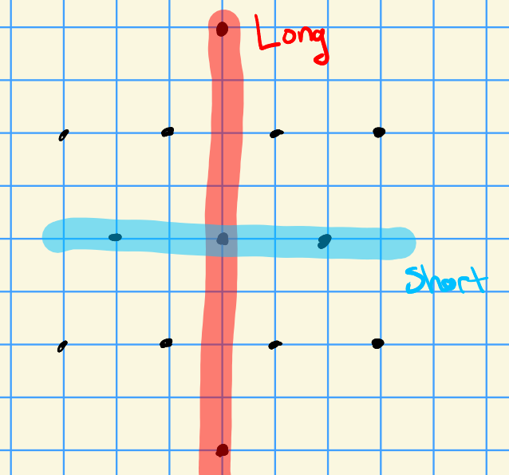

There is an action of $K$ on $V_\ell \mathrel{\vcenter{:}}=\operatorname{Sym}^\ell({\mathbb{C}}^2)\otimes\one$, and the diagonal acts trivially.

Suppose $\Gamma\leq {\mathsf{G}}_2$ is a congruence subgroup, so $\Gamma = {\mathsf{G}}_2({\mathbb{Q}}) \cap K_f$ where $K_f \subseteq {\mathsf{G}}_2(M_f)$, and let $\ell \in {\mathbb{Z}}_{>0}$,  
A **modular form** of weight $\ell$ and level $\Gamma$ is a map $\phi: {\mathsf{G}}_2 \to V_\ell$ such that

1. Growth: $\phi$ has moderate growth.
2. Invariance: $\phi( \gamma g) = \phi(g)$ for all $\gamma\in \Gamma$.
3. Equivariance on a compact: $\phi(gk) = k^{-1}\phi(g)$ for all $k\in K$.
4. Operator equation: $D_\ell \phi = 0$.

Equivalently, a map $\phi: \dcosetl{{\mathsf{G}}_2({\mathbb{Q}})}{{\mathsf{G}}_2({\mathbb{A}})}$ satisfying similar conditions.

The upshot: modular forms on ${\mathsf{G}}_2$ have a classical Fourier expansion and Fourier coefficients, which appear very arithmetic.

## 11.2 What is ${\mathsf{G}}_2$?

Todos:

- What is ${\mathsf{G}}_2$?
- What is $D_\ell$?
- What are some examples/theorems about modular forms on ${\mathsf{G}}_2$?

We’ll define a $C_3{\hbox{-}}$graded Lie algebra over ${\mathbb{Q}}$:
$$\begin{align*}
{\mathfrak{g}}_2 = {\mathfrak{sl}}_3[0] + V_g({\mathbb{Q}})[1] + V_3 {}^{ \vee }({\mathbb{Q}})[2]
,\end{align*}
where \({\mathfrak{sl}}_3\) are the traceless matrices as usual and \(V_3\) is the 3-dimensional standard representation of \({\mathfrak{sl}}_3\). The grading will mean that \([x,y]\) will land in degree \({\left\lvert {x} \right\rvert} + {\left\lvert {y} \right\rvert}\). The bracket is defined as follows:
\begin{align*}
[\phi, \phi'] &\mathrel{\vcenter{:}}=\phi\phi' - \phi'\phi & \phi,\phi'\in {\mathfrak{sl}}_3 \\
[\phi, v] &\mathrel{\vcenter{:}}=\phi(v), & v\in V_3\\
[\phi, \delta] &\mathrel{\vcenter{:}}=\phi(\delta),&\delta\in V_3 {}^{ \vee }
.\end{align*}$$

$$\begin{align*}
\bigwedge\nolimits^3 V_3= \one
\implies
\bigwedge\nolimits^2 V_3= V_3 {}^{ \vee }
\implies
\bigwedge\nolimits^2 (V {}^{ \vee }) = V_3
.\end{align*}
Fix a basis \(V_3 = \left\langle{v_1, v_2, v_3}\right\rangle\) and \(V_3 {}^{ \vee }= \left\langle{\delta_1, \delta_2, \delta_2}\right\rangle\) its dual basis, then$$

- $v_i \vee v_{i+1} = \delta_{i-1}$
- $\delta_i \vee\delta_{i+1} = \delta_{i-1}$

Moreover,

$$\begin{align*}
[v, v'] &= 2 v\vee v' \in \bigwedge\nolimits^2 V_3 \cong V_3 {}^{ \vee }\\
[\delta, \delta'] &= 2\delta\vee\delta' \in \bigwedge\nolimits^2 V_3 {}^{ \vee }\cong V_3 \\
[\delta, v] &= 3v\otimes\delta - \delta(v)\one \in {\mathfrak{sl}}_3
,\end{align*}
noting that the last is traceless and \(3v\otimes\delta\in V_3\otimes V_3 {}^{ \vee }\cong \mathop{\mathrm{End}}(V_3)\). All other brackets are determined by antisymmetry and linearity$$

The algebra ${\mathfrak{g}}_2$ as defined above is a simple Lie algebra, i.e. the Jacobi identity holds and there are no nontrivial ideals. Moreover
$$\begin{align*}
\mathop{\mathrm{Aut}}({\mathfrak{g}}_2) = \left\{{g\in \operatorname{GL}({\mathfrak{g}}_2) {~\mathrel{\Big\vert}~}[gx, gy] = g[x, y]\, \forall x, y \in {\mathfrak{g}}_2}\right\}
\end{align*}
and \({\mathsf{G}}_2 \cong \mathop{\mathrm{Aut}}^0({\mathfrak{g}}_2)\) is the connected component.$$

Note: a similar procedure can be used to define all of the exceptional groups, see notes.

What is the root diagram for ${\mathfrak{g}}_2$? Let ${\mathfrak{h}}\leq {\mathfrak{sl}}_3$ be the diagonal elements, i.e.
$$\begin{align*}
{\mathfrak{h}}= \left\{{\sum_{1\leq i\leq 3} \alpha_i E_{ii} {~\mathrel{\Big\vert}~}\sum \alpha_i = 0}\right\}
,\end{align*}
and let \(r_1, r_2, r_3: {\mathfrak{h}}\to {\mathbb{Q}}\) be such that
\begin{align*}
r_j \sum_{1\leq i\leq 3} \alpha_i E_{ii} = \alpha_j
,\end{align*}
i.e. projection onto the \(j\)th component. Note that \(\sum r_i = 0\).$$

What are the weights of ${\mathfrak{h}}$ on ${\mathfrak{g}}_2$? Since ${\mathfrak{g}}_2 = {\mathfrak{sl}}_3 + V_3 + V_3 {}^{ \vee }$, the actions are:

- On $V_3$ it acts by $r_1, r_2, r_3$.
- On $V_3 {}^{ \vee }$ it acts by $-r_1, -r_2, -r_3$.
- On ${\mathfrak{sl}}_3$ it acts by $\left\{{r_i - r_j {~\mathrel{\Big\vert}~}i\neq j}\right\}$.

This yields a root diagram:

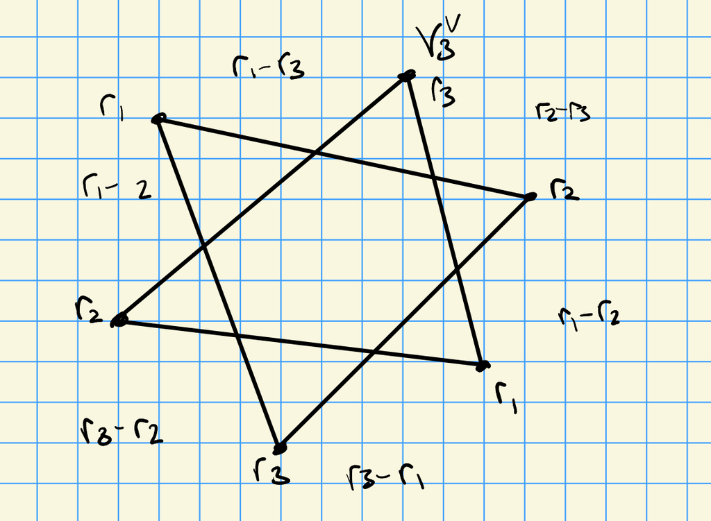

On the differential operator: take the Cartan involution
$$\begin{align*}
\Theta: {\mathfrak{g}}_2\otimes{\mathbb{R}}\to {\mathfrak{g}}_2 \otimes{\mathbb{R}}
.\end{align*}$$

Explicitly,

- On ${\mathfrak{sl}}_3$, this acts as $X\mapsto {}^{-t}X$
- On $V_3$, it’s $V_3\mapsto V_3 {}^{ \vee }$ by $v_j\mapsto \delta_j$.

Define

- $k_0 = ({\mathfrak{g}}_2\otimes{\mathbb{R}})^{G=\operatorname{id}}$
- $p_0 = ({\mathfrak{g}}_2\otimes{\mathbb{R}})^{G=-\operatorname{id}}$
- $K = \left\{{g\in {\mathsf{G}}_2 {~\mathrel{\Big\vert}~}{ \operatorname{Ad} }_g\circ \Theta = \Theta \circ { \operatorname{Ad} }_g}\right\}$
- $k = k_0 \otimes{\mathbb{C}}$, something about ${\mathfrak{sl}}_3 + {\mathfrak{sl}}_2$
- $p = p_0 \otimes{\mathbb{C}}$, something about $V_2\otimes\operatorname{Sym}^3(V_2)$.
- $D_\ell = {\operatorname{pr}}\tilde D_\ell$, which we’ll define.

Suppose $\phi: {\mathsf{G}}_2\to V_\ell = \operatorname{Sym}^{2\ell}({\mathbb{C}}^2)\otimes\one$ such that $\phi(gk) = k^{-1}\phi(g)$ for all $k\in K$. Let $\left\{{X_\alpha}\right\}$ be a basis of $p$, $\left\{{X_\alpha {}^{ \vee }}\right\}$ basis of $p {}^{ \vee }$, then
$$\begin{align*}
\tilde D_\ell \phi = \sum_\alpha X_\alpha p \otimes X_\alpha {}^{ \vee }\in V_\ell \otimes p {}^{ \vee }
.\end{align*}
where \(X_\alpha \phi\) is the derivative of the right regular action, i.e. if \(X\in p_0\),
\begin{align*}
(X_p)(g) = {\frac{\partial }{\partial t}\,} \phi(g\exp(tx))\Big|_{t=0}
.\end{align*}
Then
\begin{align*}
V_\ell \otimes\phi {}^{ \vee }
&= (S^{2\ell} \otimes\one) \times V_\ell \boxtimes\operatorname{Sym}^3(V_2) \\
&= (S^{2\ell + 1} + S^{2\ell - 1})\boxtimes S^3(V_2) \\
&\xrightarrow{{\operatorname{pr}}} S^{2\ell -1}(V_\ell) \boxtimes S^3(V_3)
.\end{align*}$$

This relates

- ${\mathsf{G}}_2\leadsto {\operatorname{SL}}_2$
- ?

# 12 Aaron Pollack, Talk 2

Last time: modular forms on ${\mathsf{G}}_2$. Note that ${\mathsf{G}}_2$ over $K$ does not have a ${\mathsf{G}}_2{\hbox{-}}$invariant complex structure, while ${\operatorname{SL}}_2({\mathbb{R}})/{\operatorname{SO}}_2 = {\mathfrak{h}}$ has an ${\operatorname{SL}}_2({\mathbb{R}}){\hbox{-}}$invariant complex structure.

Today: let $f(z) = \sum_{k\geq 0} a_f(k)q^k$ of weight $\ell$ where $\phi_f(g) = j(g, i)^{-\ell} f(gi)$ where $\phi_f: {\operatorname{SL}}_2({\mathbb{R}}) \to {\mathbb{C}}$. Define
$$\begin{align*}
W_n: {\operatorname{SL}}_2({\mathbb{R}}) &\to {\mathbb{C}}\\
g &\mapsto j(g, i)^{-\ell} \exp(2\pi i n (gi))
.\end{align*}$$

Some properties:

- $W_n\qty{{ \begin{bmatrix} {1} & {*} \\ {0} & {1} \end{bmatrix} } g} = e^{2\pi i n x}W_n(g)$
- $W_n(gk_0) = e^{-i\ell \theta} W_n(g)$ where $k_\theta = { \begin{bmatrix} {\cos(\theta)} & {-\sin(\theta)} \\ {\sin(\theta)} & {\cos(\theta)} \end{bmatrix} }$,
- $X_- W_n = 0$
- $W_n \operatorname{diag}(y^{1\over 2}, y^{-{1\over 2}}) = y^{\ell\over 2} e^{2\pi i ny}$ is complete explicit
- $\phi_f(g) = \sum a_f(k) W_k(g)$ is the Fourier expansion.

What will happen: we’ll define $\phi: \dcosetl{\Gamma}{{\mathsf{G}}_2}\to V_\ell$ where $V_\ell = \operatorname{Sym}^2({\mathbb{C}}^2)\otimes\one$ which admits an action by $K = {\operatorname{SU}}_2\times {\operatorname{SU}}_2/\pm I$. In this case, we’ll essentially have $\phi \approx \sum_{f\in ?} a_\phi(f) W_f(g)$ where the $a_\pi(f) \in {\mathbb{C}}$ are Fourier coefficients and $W_f$ satisfies similar properties.

Recall that ${\mathfrak{g}}_2 = {\mathfrak{sl}}_3 + V_3 + V_3 {}^{ \vee }$, spanned by $\left\{{E_{ij}}\right\}, \left\{{v_1,v_2,v_3}\right\}, \left\{{\delta_1, \delta_2, \delta_3}\right\}$ respectively.

Note that

- ${\mathsf{G}}_2$ has 2 conjugacy classes of maximal parabolics,
- $P$ will be the parabolic where $\mathsf{Lie}(P)$ yields the top 3 layers of the root diagram
- $P = MN$ where $M\cong \operatorname{GL}_2$ and $N\supseteq Z = [N, N]$ with $N/Z$ abelian.

We want to define a Fourier expansion along the unipotent radical of $P$.

Some facts:

- $Z = \exp({\mathbb{R}}E_{13})$
- $W = {\mathbb{R}}E_{12} + {\mathbb{R}}v_1 + {\mathbb{R}}\delta_3 + {\mathbb{R}}E_{23}$
- $N/Z = \exp(W)$
- $M\curvearrowright Z$ by the determinant
- $M\curvearrowright N/Z$ as $\operatorname{Sym}^3(V_3) \otimes\operatorname{det}(V_3)^{-1}$
- There is a symplectic form on $W$ where $[w, w'] = {\left\langle {w},~{w'} \right\rangle} E_{13}$
- Explicitly, one can write $w = \sum a E_{12} + {b\over 3} v_1 + {c\over 3} \delta_3 + d E_{13}$ and $w'$ similarly, then ${\left\langle {w},~{w'} \right\rangle} = ad' - {bc'\over 3} + {cb'\over 3}- da'$, and ${\left\langle {mw},~{mw'} \right\rangle} = \operatorname{det}(m) {\left\langle {w},~{w'} \right\rangle}$.

What are the characters of $N$? Suppose

- $\phi$ is an automorphic form on ${\mathsf{G}}_2({\mathbb{A}})$
- $\psi: \dcosetl{{\mathbb{Q}}}{{\mathbb{A}}}\to {\mathbb{C}}^{\times}$ is a fixed adelic character
- $w\in W({\mathbb{Q}})$

Define
$$\begin{align*}
\phi_w(g) \mathrel{\vcenter{:}}=\int_{[N]} \psi^{-1}({\left\langle {w},~{\mkern 1.5mu\overline{\mkern-1.5mun\mkern-1.5mu}\mkern 1.5mu} \right\rangle}) \phi(ng) \,dn
,\end{align*}
where \(\mkern 1.5mu\overline{\mkern-1.5mun\mkern-1.5mu}\mkern 1.5mu\) is the image of \(n\) in \(N/Z\) which we identify with \(W\) via the exponential. Similarly define
\begin{align*}
\phi_Z(g) = \int_{[Z]} \phi(zg)\,dz,\qquad
\phi_N(g) = \int_{[N]} \phi(zg)\,dz
.\end{align*}
Then
\begin{align*}
\phi_Z(g) = \phi_N(g) + \sum_{w\in W({\mathbb{Q}})} \phi_w(g)
,\end{align*}
and we’ll produce a refinement.$$

$$\begin{align*}
\phi_Z(g) \equiv 0 \implies \phi(g) \equiv 0
.\end{align*}$$

## 12.1 Generalized Whittaker Functions

Suppose $\phi: \dcosetl{{\mathsf{G}}_2({\mathbb{Q}})}{{\mathsf{G}}_2({\mathbb{A}})} \to V_\ell$ is a modular form of weight $\ell$. These satisfy

- $\phi_w(g)$ is of moderate growth.
- $\phi_w(g) = \psi({\left\langle {w},~{\mkern 1.5mu\overline{\mkern-1.5mun\mkern-1.5mu}\mkern 1.5mu} \right\rangle}) \psi_W(g)$ (equivariant for the Heisenberg parabolic)
- $\phi_w(gk) = k^{-1}\phi_w(g)$ (equivariant for $K$)
- $D_\ell \phi_w = 0$.

Call such functions satisfying these properties **general Whittaker functions of type $(w ,\ell)$**.

We’ll show that such functions are uniquely determined up to a scalar multiple, i.e. for some explicit $W_w$,
$$\begin{align*}
\phi_w(g) = \lambda W_w(g)
.\end{align*}
From this, we’ll obtain a Fourier expansion for \(\phi\) a modular form of weight \(\ell\):
\begin{align*}
\phi_Z(g) = \phi_N(g) + \sum_{w\neq 0} a_{\phi}(w) W_w(g)
.\end{align*}$$

Identify $W$ as a space $B$ of binary cubics under
$$\begin{align*}
W &\to B \\
w \mathrel{\vcenter{:}}= a E_{12} + {b\over 3} v_1 + {c\over 3} \delta_3 + d E_{23}
&\mapsto
f_w\mathrel{\vcenter{:}}=
au^3 + bu^2v + cuv^2 + dv^3
.\end{align*}
For \(w\in W({\mathbb{R}})\setminus\left\{{0}\right\}\), for \(m\in \operatorname{GL}_2({\mathbb{R}})\) define
\begin{align*}
\beta_w(m) \mathrel{\vcenter{:}}={\left\langle {w},~{m\cdot (u-? v)^3} \right\rangle}
,\end{align*}
which will appear in Fourier expansions.$$

TFAE:

- $\beta_w(m) \neq 0$ for all $m\in \operatorname{GL}_2({\mathbb{R}})$,
- $f_w(z, 1) \neq 0$ for $z\in {\mathfrak{h}}$,
- $f_w$ splits into linear factors over ${\mathbb{R}}$.

If $w$ satisfies these properties, say $w$ is **positive semidefinite** and write $w\geq 0$.

- $f_w(u, v) \mathrel{\vcenter{:}}= au^3 \geq 0$.
- $f_w(u, v) \mathrel{\vcenter{:}}=-u^3 + uv^2 = u(v-u)(v+u)\geq 0$.
- $f_w(u, v) \mathrel{\vcenter{:}}= u^3 + v^2 \not\geq 0$.

For $m\in \operatorname{GL}_2({\mathbb{R}}) = M({\mathbb{R}})$ and $w\geq 0$ PSD,
$$\begin{align*}
W_w(m) = {\left\lvert {\operatorname{det}w} \right\rvert}\operatorname{det}(w)^\ell \sum_{-\ell \leq v\leq 0}
\qty{{\left\lvert {\beta_w(m)} \right\rvert} \over \beta_w(m) }^v K_v({\left\lvert {\beta_w(m)} \right\rvert}) {x^{\ell+v} y^{\ell -v} \over (\ell+v)! (\ell-v)!}
.\end{align*}
where \(x,y\) are a fixed basis of \(V_\ell\), and \(K_v\) is a classical \(K{\hbox{-}}\)Bessel function
\begin{align*}
K_v(y) \mathrel{\vcenter{:}}={1\over ?}\int_0^N e^{-{y(t+t^{-1})\over 2 }} t^v {\,dt\over t}
,\end{align*}
which diverges at \(y=0\).$$

These functions $W_w: M({\mathbb{R}}) \to V_\ell$ extend uniquely to ${\mathsf{G}}_2\to V_\ell$, viz

- $W_w(ng) = e^{2\pi i {\left\langle {w},~{\mkern 1.5mu\overline{\mkern-1.5mun\mkern-1.5mu}\mkern 1.5mu} \right\rangle}} W_w(g)$ for all $n\in N({\mathbb{R}})$
- $W_w(gk) = k^{-1}W_w(g)$ for all $k\in K$.

Suppose $w\neq 0$ and $F$ is a generalized Whittaker function of type $(w, \ell)$. Then

- $w\not\geq 0\implies F = 0$
- $w\geq 0\implies F(g) = \lambda W_w(g)$ for some $\lambda \in {\mathbb{C}}$

Consequently, if $\phi$ is a modular form on ${\mathsf{G}}_2$ of weight $\ell$, there exist $a_\phi(w)\in {\mathbb{C}}$ with
$$\begin{align*}
\phi_Z(g) = \phi_N(g) + \sum_{w\geq 0 \text{ integral}} a_\phi(w) W_w(g)
.\end{align*}
Moreover, \(\phi_N\) can be explicitly described in terms of modular forms of weight \(3\ell\) on \(\operatorname{GL}_2\).$$

The terms $a_\phi(w)$ are by definition the Fourier coefficients of $\phi$.

Gan-Gross-Savim used a multiplicity 1 result of Wallach to define the Fourier coefficients without using the explicit function $W_w(s)$.

# 13 Aaron Pollack, Talk 3: Examples of (and theorems about) modular forms on ${\mathsf{G}}_2$

## 13.1 Degenerate Eisenstein Series

Recall ${\mathsf{G}}_2\supseteq P$ a Heisenberg parabolic, with $P = MN$ where $M\cong \operatorname{GL}_2$. Write $\nu$ for the composition $P\to M \xrightarrow{\operatorname{det}} \operatorname{GL}_1$. Suppose $\ell > 0$ is even, and recall that $V_\ell = \operatorname{Sym}^2({\mathbb{C}}^2)\otimes\curvearrowleft K \leq {\mathsf{G}}_2$ for $K$ a maximal compact. Let
$$\begin{align*}
f_{\ell, \infty} (g; s) = \operatorname{Ind}_{P({\mathbb{R}})}^{{\mathsf{G}}_2({\mathbb{R}})} {\left\lvert {\nu} \right\rvert}^s \otimes V_\ell
\end{align*}
be defined by$$

$$\begin{align*}
f_{\ell, \infty}(pg^j s) &= N(\mu)^s f_{e\ll, \infty} (g; s) \quad \forall p\in P({\mathbb{R}}) \\
f_{\ell,\infty}(gk; s) &= k^{-1}f_{\ell, \infty}(g) \quad \forall k\in K
.\end{align*}$$

By the Iwasawa decomposition $C_3({\mathbb{R}}) = P({\mathbb{R}}) K$, $f$ is uniquely determined one we set
$$\begin{align*}
f_{\ell, \infty}(1) = x^\ell y^\ell \in V_\ell = \left\langle{x^?, x^?, \cdots, y^{2\ell}}\right\rangle
.\end{align*}
Let \(f_?\) be a flat section in \(\operatorname{Ind}_{P({\mathbb{A}}_f)}^{{\mathsf{G}}_2({\mathbb{A}}_f)}({\left\lvert {\nu} \right\rvert}^3)\), and let \(f_g(g, s) = f_?(gf, s) f_{\ell,\infty}(g_?; s) \in {\mathsf{G}}_2({\mathbb{A}})\). Define
\begin{align*}
E_\ell(g,f,s) = \sum_{\gamma\in \dcosetl{P({\mathbb{Q}})}{ {\mathsf{G}}_2({\mathbb{Q}})} } f_\ell(\gamma g, s)
.\end{align*}
If \(\Re(s) > 3\), set \(E_\ell(g) \mathrel{\vcenter{:}}= E_\ell(g, f, s=\ell+1)\).$$

If $\ell>0$ is even and $\ell\geq 4$, then $E_\ell(g)$ is a quaternionic modular form on ${\mathsf{G}}_2$ of weight $\ell$.

$f_{\ell, ?}(g, s=\ell+1)$ is annihilated by $D_\ell$, so $E_\ell(g)$ is as well by absolute convergence.

If $\pi$ is a cuspidal automorphic representation of $\operatorname{GL}_2 = M$ associated to a holomorphic weight $3\ell$ modular form which is cuspidal,

- $f_\pi\in \operatorname{Ind}_{P({\mathbb{A}})}^{{\mathsf{G}}_2({\mathbb{A}})}(\pi)$
- $E(g, f_\pi) = \sum_{ \gamma\in \dcosetl{P({\mathbb{Q}})}{{\mathsf{G}}_2({\mathbb{Q}})} } f_\pi( \gamma g)$
- If $\ell \geq 6$ this is a weight $\ell$ modular form on ${\mathsf{G}}_2$.
- If $\ell=4$, one can make sense of $E(g, f_\pi)$ using analytic continuation to produce a weight 4 modular form on ${\mathsf{G}}_2$ associated to the Ramanujan $\Delta$.

If $\phi$ is a level 1 quaternionic modular form on ${\mathsf{G}}_2$,

- $a_\phi(w) \neq 0 \implies f_w(u, v)= au^3 + \cdots + dv^3$ with $a,\cdots,d\in {\mathbb{Z}}$ (integrality)
- $a_p(w\gamma) = \operatorname{det}(\gamma)^\ell a_\phi(w)$ for $r\in \operatorname{GL}_2({\mathbb{Z}})$, so Fourier coefficients are constant on orbits of binary cubic forms.

There is a bijection
$$\begin{align*}
\left\{{\text{Integral binary cubic forms}}\right\}/\operatorname{GL}_2({\mathbb{Z}})
\rightleftharpoons
\left\{{\text{Cubic rings}}\right\}{_{\scriptstyle / \sim} }
,\end{align*}
where cubic rings are free rank 3 \({\mathbb{Z}}{\hbox{-}}\)algebras. Thus if \(\ell>0\) is even, \(\phi\) is a level 1 weight \(\ell\) modular form on \({\mathsf{G}}_2\), and \(A\) is a cubic ring, there is a well-defined map \(a_\phi(A) = a_\phi(w)\) if \(A\rightleftharpoons f_w\).$$

If $f_w$ is nondegenerate, the cubic ring $A(f_w)$ associated to $f_w$ is totally real $\iff f$ is positive semidefinite.

Suppose $A$ is the maximal order in a totally real cubic etale ${\mathbb{Q}}{\hbox{-}}$algebra $E$. There exists a constant $c_\ell\in {\mathbb{C}}$, independent of $A$, such that
$$\begin{align*}
a_{E_\ell}(A) = c_\ell \zeta_E(1-\ell)
,\end{align*}
where \(\ell\) is even. The LHS are Fourier coefficients of modular forms on \({\mathsf{G}}_2\).$$

It is not known that $c_\ell$ is nonzero.

An open question: $E(g, f_\pi)$ is Eisenstein, can anything be said about its Fourier coefficients.

## 13.2 Cusp Forms

Suppose $\ell\geq 16$ is even. There exist nonzero cusp forms on ${\mathsf{G}}_2$ of weight $\ell$, all of whose Fourier coefficients are algebraic integers.

Steps:

1. Start with a holomorphic Siegel modular form $f$ on ${\operatorname{SP}}_4$ of weight $\ell$, so $f$ has Fourier coefficients in ${ \mkern 1.5mu\overline{\mkern-1.5mu \mathbb{Z} \mkern-1.5mu}\mkern 1.5mu }$
2. Take a $G{\hbox{-}}$lift of $f$ to ${\operatorname{SO}}_{4,4}$ to obtain $G(f)$, and define
   $$\begin{align*}
   \Theta(f)(g) = \int_{[{\operatorname{SP}}_4]} \theta(g, h) \mkern 1.5mu\overline{\mkern-1.5muf(h)\mkern-1.5mu}\mkern 1.5mu \, dh
   ,\end{align*}
   then \(\Theta\) on \({\operatorname{SO}}_{4,4}\times {\operatorname{SP}}_4\) is a \(\theta\) function.$$
3. There is a good theory of quaternionic modular forms on ${\operatorname{SO}}_{4, n}$, so choose $\theta(g,h)$ such that $\Theta(f)$ is a one of weight $\ell$ (and cuspidal).
4. Express the Fourier coefficients of $\Theta(f)$ in terms of classical Fourier coefficients of $f$, showing that the Fourier coefficients of $G(f)$ are in ${ \mkern 1.5mu\overline{\mkern-1.5mu \mathbb{Z} \mkern-1.5mu}\mkern 1.5mu }$.
5. Use ${\mathsf{G}}_2 \xhookrightarrow{\iota}{\operatorname{SO}}_{4,4}$ and pullback to obtain $i^*(\Theta(f))$, which is still cuspidal and has Fourier coefficients that are sums of the original coefficients, so still in ${ \mkern 1.5mu\overline{\mkern-1.5mu \mathbb{Z} \mkern-1.5mu}\mkern 1.5mu }$.

There is an explicit dimension formula for the level 1 cuspidal quaternionic modular forms of weight $\ell$. In particular, the smallest is a level 1 cusp form of weight 6.

Suppose $\phi$ is a level 1 cuspidal quaternionic modular form on ${\mathsf{G}}_2$ associated to a cuspidal automorphic representation $\pi$ on ${\mathsf{G}}_2({\mathbb{A}})$. Suppose that the Fourier coefficient $a_\phi({\mathbb{Z}}{ {}^{ \scriptscriptstyle\times^{3} } }) \neq 0$, then

1. The complete standard $L{\hbox{-}}$function of $\pi$ has a functional equation:
   $$\begin{align*}
   \Lambda(\pi, \text{std}, s) = \Lambda(\pi, \text{std}, 1-s)
   .\end{align*}$$
2. There exists a Dirichlet series for this $L{\hbox{-}}$function expressing the Fourier coefficients in terms of an $L{\hbox{-}}$function:
   $$\begin{align*}
   \sum_{T \subseteq {\mathbb{Z}}{ {}^{ \scriptscriptstyle\times^{3} } },n\geq 1} {a_\phi({\mathbb{Z}}+ nT) \over [{\mathbb{Z}}{ {}^{ \scriptscriptstyle\times^{3} } } : T]^{s-\ell+1} }n^{-s}
   =
   a_p({\mathbb{Z}}{ {}^{ \scriptscriptstyle\times^{3} } }) {L(\pi, \text{std}, s-z\ell+1) \over \zeta(s-2\ell + 2)^2 \zeta(2s-4\ell+2) }
   .\end{align*}$$

Carry out a refined analysis of a Rankin-Selberg integral (due to Gurevich-Segal).

## 13.3 A Theorem

There is a theory of *half*-integral weight modular forms on ${\mathsf{G}}_2$. These have a good notion of Fourier coefficients taking values in ${\mathbb{C}}/\left\{{\pm 1}\right\}$.

Suppose $R \subseteq E$ is a cubic ring in a totally real cubic field. Let ${\partial}_R$ be the different, and let $Q_R$ be the square roots of ${\partial}_R^{-1}$ in the narrow class group of $E$. Say $(I, \mu)$ is balanced

- $I$ is a fractional ideal in $R$.
- $\mu\in E_{>0}^{\times}$ is totally positive
- $I \mu^2 \subseteq \partial_R^{-1}$
- $N(I)^2 N(\mu) {\operatorname{disc}}(R) = 1$.

Note that if $R$ is the maximal order, $(I, \mu)$ is balanced iff $I^2\mu = {\partial}_R^{-1}$. Define an equivalence relation by
$$\begin{align*}
(I, \mu) \sim (I', \mu') \iff \exists \beta\in E^{\times}, I' = \beta I, \mu' = \beta^{-2}\mu
\end{align*}
and set \(Q_R\) to be the balanced pairs mod equivalence.$$

- $Q_R$ can be empty
- For $Q_R$ nonempty and $R$ a maximal order in $E$,
  $$\begin{align*}
  {\left\lvert {Q_R} \right\rvert} = {\sharp}{ \operatorname{Cl}} E^{\times}[2]
  .\end{align*}$$

There exists a weight $1/2$ modular form $\theta'$ on ${\mathsf{G}}_2$ whose Fourier coefficients include the numbers $\pm {\left\lvert {Q_R} \right\rvert}$ for $R$ *even monogenic*, i.e.
$$\begin{align*}
R = {\mathbb{Z}}[y]/ \left\langle{y^3 + cy^2 + by+a, a,b,c\in 2{\mathbb{Z}}}\right\rangle
.\end{align*}$$

Define $\Theta$ on $\tilde {\operatorname{F}}_4$? Then let $\Theta'$ be a pullback along ${\mathsf{G}}_2\to {\operatorname{F}}_3$.

# 14 Aaron Pollack, Talk 4: Beyond ${\mathsf{G}}_2$

Upshot for today: there exist groups ${\mathsf{G}}_3, {\operatorname{F}}_4, {\mathbf{E}}_{n, 4}$ for $n=6,7,8$ where ${\mathsf{G}}_2$ is split and the ${\mathbf{E}}$ groups are rank 4 over ${\mathbb{R}}$. These admit modular forms with Fourier expansions and coefficients similar to the ${\mathsf{G}}_2$ story. We’ll define these exceptional groups today.

## 14.1 Exceptional Algebras

Let be a composition algebra over $k$, where $\operatorname{ch}k = 0$, with a multiplication $C{ {}^{ \scriptstyle\otimes_{k}^{2} } }\to C$ which is not necessarily commutative or associative. There exists a norm map $n_C: C\to K$ given by a nondegenerate quadratic form with $n_C(xy) = n_C(x) n_C(y)$.

- $C = k$ and
  $$\begin{align*}
  n_c: k &\to k \\
  x&\mapsto x^2
  .\end{align*}$$
- $C = E/k$ for $E$ a quadratic etale extension, $n_C = \operatorname{Nm}_{E/k}$.
- $C = B/k$ for $B$ a quaternion algebra with $n_C = n_{B, { \text{red} }}$
- $C = \Theta$ an octonion algebra, with $\Theta = B \bigoplus B$. There is an involution $C\to C$ with
  - $x + x^* = \operatorname{Trace}_C(x) 1\in k1$,
  - $xx^* = n_C(x)1\in k1$

Let $J_C = H_3(C)$ be Hermitian $3\times 3$ matrices with coefficients in $C$, so
$$\begin{align*}
J_C = \left\{{
\begin{bmatrix}
c_1 & x_3 & x_2^* \\
x_3^* & c_2 & x_1 \\
x_2 & x_1^* & c_3
\end{bmatrix}
{~\mathrel{\Big\vert}~}c_i\in k, c_i\in C
}\right\}
.\end{align*}
This has dimension \(3+3C\) over \(k\).$$

For $C=k, H_3(K)$ are symmetric $3\times 3$ matrices and there is a determinant map
$$\begin{align*}
\operatorname{det}: J_C &\to k \\
X&\mapsto c_1c_2 c_3 - \sum c_i n_C(x_i) + \operatorname{Trace}_C(x_1(x_2 x_3))
.\end{align*}$$

If $C=k$ this is the usual determinant. Note that $M_J' = \left\{{g\in \operatorname{GL}(J_C) {~\mathrel{\Big\vert}~}\operatorname{det}(gX) = \operatorname{det}(X) \forall X\in J_C}\right\}$ has positive dimension, and is thus infinite, making it an interesting algebra.

Idea: there exists a group $G_{J_C}$ such that

- $C = {\mathbb{Q}}\leadsto {\operatorname{F}}_4$,
- $C = K$ quadratic imaginary $\leadsto {\mathbf{E}}_{6,4}$,
- $C= B$ a quaternionic algebra $\leadsto {\mathbf{E}}_{7,4}$,
- $C = \Theta$ an octonionic algebra $\leadsto {\mathbf{E}}_{8, 4}$.

All have a good notion of quaternionic modular forms and Fourier expansions/coefficients.

A degree map $J_C \xrightarrow{\deg} k$ commuting with $x\mapsto x^3$ and $\operatorname{det}$ recovers $G_{J_C = k} = {\mathsf{G}}_2$. Recall
$$\begin{align*}
{\mathfrak{g}}_2 = {\mathfrak{sl}}_{2, \ell}[0] + {\mathfrak{sl}}_{2, s}[0] + V_2 \otimes W[1]
\end{align*}
which is \(C_2{\hbox{-}}\)graded; we’ll mimic this to construct \({\mathfrak{g}}_{J_C}\).$$

## 14.2 Freudenthal Construction

Let $J = J_C/{\mathbb{Q}}$ and $k={\mathbb{Q}}$ and
$$\begin{align*}
W_J = {\mathbb{Q}}\bigoplus J \oplus J {}^{ \vee }\oplus {\mathbb{Q}}
.\end{align*}
There is a symplectic form
\begin{align*}
{\left\langle {{\left[ {a,b,c,d} \right]}},~{{\left[ {a,b,c,d} \right]}} \right\rangle} = ad' - (b,c') - (c, b') - dc'
.\end{align*}
There is a degree 4 polynomial map \(q: W_J\to {\mathbb{Q}}\). Define
\begin{align*}
H_J^1 = \left\{{g\in \operatorname{GL}(W_J) {~\mathrel{\Big\vert}~}{\left\langle {gw},~{gw'} \right\rangle} = {\left\langle {w},~{w'} \right\rangle} \,\forall w,w'\in W_J,\, q(gw) = q(w)}\right\}
.\end{align*}
This recovers:$$

| $C$ | $H_J^1$ | ${\mathfrak{g}}_J$ |
| --- | --- | --- |
| ${\mathbb{Q}}$ | $\operatorname{C}_3$ | ${\operatorname{F}}_4$ |
| $K$ | $\operatorname{A}_5$ | ${\mathbf{E}}_6$ |
| $B$ | ${ \mathsf{D} }_6$ | ${\mathbf{E}}_7$ |
| $\Theta$ | $E_7$ | ${\mathbf{E}}_8$ |

Define
$$\begin{align*}
{\mathfrak{g}}_J ={\mathfrak{sl}}_2[0] + {\mathfrak{h}}_J^0[0] + (V_2\otimes W_J)[1]
,\end{align*}
where \({\mathfrak{h}}_J^0 = \mathsf{Lie}(H_J^1)\), and define
\begin{align*}
G_J \mathrel{\vcenter{:}}=\mathop{\mathrm{Aut}}^0({\mathfrak{g}}_J)
.\end{align*}$$

If $n_C: C\otimes{\mathbb{R}}\to {\mathbb{R}}$ is positive definite, we say ${\mathsf{G}}_J$ is a **quaternionic exceptional group**.

If $K_J \subseteq {\mathsf{G}}_J({\mathbb{R}})$ is a maximal compact, then
$$\begin{align*}
K_J = {{\operatorname{SU}}_2 \times L_J' \over \mu_2}
\end{align*}
where \(L_J^1\) is a compact form of \(H_J^1\).$$

There is a Cartan involution $\theta: {\mathfrak{g}}_J\to {\mathfrak{g}}_J$, which over ${\mathbb{C}}$ yields
$$\begin{align*}
{\mathfrak{g}}_J^{\theta = \operatorname{id}} &= k_0\otimes{\mathbb{C}}\cong {\mathfrak{sl}}_2 + {\mathfrak{h}}_J^0 \\
{\mathfrak{g}}_J^{\theta = -\operatorname{id}} &= p_0\otimes{\mathbb{C}}\cong V_2 + W_J
.\end{align*}$$

There is an action $K_J\curvearrowright V_\ell = \operatorname{Sym}^{2\ell}({\mathbb{C}}^2)\otimes\one$

A **modular form** on ${\mathsf{G}}_3$ of weight $\ell$ is an automorphic form
$$\begin{align*}
\phi: \dcosetl{G_J({\mathbb{R}})}{G_J({\mathbb{A}})} \to V_\ell
\end{align*}
such that$$

1. $\phi(gk) = k^{-1}\phi(g)$ for all $k\in K_J$
2. $D_\ell \phi \equiv 0$

Here $D_\ell$ is defined as in the ${\mathsf{G}}_2$ case, replacing $\operatorname{Sym}^3(V_2) = W$ with $W_J$.

There is a Heisenberg parabolic $P = MN \leq G_J$ with $M = H_J$, and $N \supseteq Z$ a two-step filtration with $Z$ 1-dimensional and $N/Z \cong W_J$ abelian.

Modular forms on $G_J$ of weight $\ell$

1. Have Fourier coefficients and expansions along $N/Z$:
   $$\begin{align*}
   \phi_Z(g) = \phi_N(g) + \sum_{w\in W_J({\mathbb{Q}}), w\geq 0} a_\phi(w) W_w(g)
   ,\end{align*}
   where \(a_\phi(w)\in {\mathbb{C}}\) are the Fourier coefficients of \(\phi\) and \(W_w\) are completely explicit.$$
2. Under appropriate embeddings
   $$\begin{align*}
   {\mathsf{G}}_2 \hookrightarrow{\operatorname{F}}_4 \hookrightarrow{\mathbf{E}}_{6,4}\hookrightarrow E_{7,4} \hookrightarrow E_{8,4}
   ,\end{align*}
   for a modular form \(\phi\) of weight \(\ell\) of one groups, the pullbacks \(i^* \phi\) to a smaller group are again modular forms of weight \(\ell\) whose Fourier coefficients are sums of Fourier coefficients of \(\phi\).$$
1. There exists a nonzero weight 4 modular form $\theta_{\min}$ on ${\mathbf{E}}_{8, 4}$ with rational Fourier coefficients.
2. There exists a nonzero weight 8 modular form $\tilde\theta_{\min}$ on ${\mathbf{E}}_{8, 4}$ with rational Fourier coefficients.
- Construct $\tilde\theta_{\min}$ using Eisenstein series
- Savim: most of the Fourier coefficients are zero, particularly the ones that are harder to compute explicitly
- By explicit computations, the remaining coefficients are rational.

Say a modular form $\phi$ on ${\mathsf{G}}_3$ is **distinguished** iff

- There exists a $w_0\in W_J({\mathbb{Q}})$ such that $q(W_0)\neq 0$ and $a_\phi(w_0) \neq 0$
- If $w\in W_J({\mathbb{Q}}), a_\phi(w)\neq 0$, then $q(w)\equiv q(w_0) \operatorname{mod}({\mathbb{Q}}^{\times}){ {}^{ \scriptscriptstyle\times^{2} } }$.

Suppose $K/{\mathbb{Q}}$ is quadratic imaginary, then there exists a distinguished modular form of weight 4 $\Theta_K$ on $G_{J_K} = {\mathbf{E}}_{6,4}$.

Set $\Theta_K i^*(\Theta_{\min})$, pullback to ${\mathbf{E}}_{6,4}$. By arithmetic invariant theory, one shows it is distinguished.

# 15 Zhiwei Yun: Rigidity method for automorphic forms over function fields (Lecture 1)

Goal: construct automorphic data over function fields and working out the Langlands correspondence for such examples. Setup:

- $k= {\mathbb{F}}_q$,
- $X_{/ {k}}$ a projective, smooth, geometrically connected algebraic curve.[^1]
- $F\mathrel{\vcenter{:}}= k(X)$ its function field, noting that $\operatorname{trdeg}F = 1$.
- ${\left\lvert {X} \right\rvert} \mathrel{\vcenter{:}}={\operatorname{Places}}(X)$, and ${\mathcal{O}}_x \twoheadrightarrow k_x$ with $F_x \subseteq {\mathcal{O}}_x$, $F_x = k_x{\left(\left( t_x \right)\right) }$ will be formal Laurent series and ${\mathcal{O}}_x \cong k{\left[\left[ t_x \right]\right] }$.
- $G_{/ {k}}$ a split semisimple group, e.g. $G={\operatorname{SL}}_n, \operatorname{PGL}_n, {\mathsf{Sp}}_{2n}, {\mathsf{G}}_2, {\mathbf{E}}_8,\cdots$
- The adeles ${\mathbb{A}}= \prod^{\operatorname{res}}_{x\in {\left\lvert {X} \right\rvert}} F_x$, where the $F_x$ will be nonarchimedean fields,
- $G({\mathbb{A}}) = \prod^{\operatorname{res}}_{x\in {\left\lvert {X} \right\rvert}} G(F_x)$ where almost all components are in $G({\mathcal{O}}_x)$.
- Level groups:
  - $K = \prod^{\operatorname{res}}_{x\in {\left\lvert {X} \right\rvert}} K_x$ where $K_x \subseteq G(F_x)$ is a compact open and almost all $K_x = G({\mathcal{O}}_x)$.
  - $K^\natural = \prod_{x\in {\left\lvert {X} \right\rvert}} G({\mathcal{O}}_x)$
- Automorphic functions
  $$\begin{align*}
  {\mathcal{A}}_K = C^0\qty{\dcoset{G(F)}{G({\mathbb{A}})}{K} \to {\mathbb{C}}}
  .\end{align*}
  Typically \(\dim {\mathcal{A}}_K = \infty\), admits a left action by the Hecke algebra
  \begin{align*}
  {\mathcal{H}}_K \mathrel{\vcenter{:}}= C_c^0\qty{\dcoset{K}{G({\mathbb{A}})}{K} \to {\mathbb{C}}}
  \end{align*}
  (the compactly supported functions) equipped with convolution with unit given by the characteristic function \(\chi_K\) and is defined as
  \begin{align*}
  (f\ast g): {\mathbb{G}}({\mathbb{A}}) &\to {\mathbb{C}}\\
  x &\mapsto \sum_{g\in \dcosetr{ G({\mathbb{A}})}{K} } f(xg) h(g^{-1})
  ,\end{align*}
  where this sum is finite due to the compact support condition.$$
- ${\mathcal{A}}_{K, c}$ the compactly supported functions in ${\mathcal{A}}_K$.
- Cusp forms ${\mathcal{A}}_{K, { \mathrm{cusp} }} = \left\{{f\in {\mathcal{A}}_{K, c} {~\mathrel{\Big\vert}~}\dim_{\mathbb{C}}{\mathcal{H}}_K \cdot f < \infty}\right\}$.
- Eigenforms $f$: $f$ such that for almost all places $x$, $f$ is an eigenvector for the action of
  $$\begin{align*}
  {\mathcal{H}}_{K_x} = C_c(\dcoset{K_x}{G(F_x)}{K_x} \to {\mathbb{C}})
  .\end{align*}$$

The goal of this theory is to study ${\mathcal{A}}_K$ as an object of $\mathsf{ {\mathcal{H}}_K}{\hbox{-}}\mathsf{Mod}$.

Define
$$\begin{align*}
{\mathsf{Bun}}_G = \left\{{G{\hbox{-}}\text{bundles on } X}\right\} \cong \dcoset{G(F)}{G({\mathbb{A}})}{K^\natural}, \qquad K^\natural \cong \prod_{x\in {\left\lvert {X} \right\rvert}} G({\mathcal{O}}_x)
.\end{align*}$$

For $G = \operatorname{GL}_n$, passing from a vector bundle to its frame bundle yields a bijection
$$\begin{align*}
\left\{{\operatorname{GL}_n{\hbox{-}}\text{bundles}}\right\} &\rightleftharpoons\left\{{\text{Vector bundes of rank } n}\right\} \\
\operatorname{\mathcal{\mathop{\mathrm{Isom}}}}({\mathcal{O}}{ {}^{ \scriptscriptstyle\oplus^{n} } }, {\mathcal{E}})\curvearrowleft\operatorname{GL}_n &\mapsfrom {\mathcal{E}}
,\end{align*}
where the Isom sheaf is regarded as principal \(G{\hbox{-}}\)bundles over \(X\). This generalizes the frame bundle construction.$$

Due to Weil: enrich to sets with automorphisms, i.e. groupoids. Then there is an equivalence of groupoids
$$\begin{align*}
\dcoset{\operatorname{GL}_n(F)}{\operatorname{GL}_n({\mathbb{A}})}{K^\natural} &{ { \, \xrightarrow{\sim}\, }}\mathsf{VectBun}_n(X)
.\end{align*}$$

Let $(g_x) \in \operatorname{GL}_n({\mathbb{A}})$ and assume $g_x = 1$ for all $x\neq x_0$. Assign a lattice in the local field
$$\begin{align*}
\Lambda_{x_0} \mathrel{\vcenter{:}}= g_{x_0} {\mathcal{O}}_{x_0}{ {}^{ \scriptscriptstyle\oplus^{n} } } \subseteq F_{x_0}{ {}^{ \scriptscriptstyle\oplus^{n} } }
,\end{align*}
which is an \({\mathcal{O}}_{x_0}\) submodule of rank \(n\). Now construct a bundle by gluing with the trivial bundle on \(X\) away from \(x_0\), so glue \(\Lambda_{x_0}\) with \({\mathcal{O}}_{X\setminus x_0}{ {}^{ \scriptscriptstyle\oplus^{n} } }\) in the following way: let \(j: X\setminus\left\{{x_0}\right\} \to X\) and form \(j_* {\mathcal{O}}_{X\setminus x_0}{ {}^{ \scriptscriptstyle\oplus^{n} } }\), which is no longer coherent and it quasicoherent, so looks like meromorphic functions but with no control on the poles. For \(U \subseteq X\) an affine open, take the functions regular away from \(x_0\) and constrain its behavior at \(x_0\) and take the sheaf associated to the following:
\begin{align*}
U\mapsto {{\Gamma}\qty{U\setminus\left\{{ x_0 }\right\}; {\mathcal{O}}_X{ {}^{ \scriptscriptstyle\oplus^{n} } } } }\cap\Lambda_{x_0} \subseteq F_{x_0}{ {}^{ \scriptscriptstyle\oplus^{n} } }
.\end{align*}$$

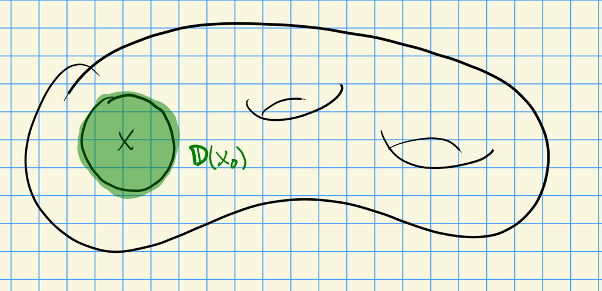

For $t_{x_0}$ a uniformizer, set $g_{x_0} = \operatorname{diag}(t_{x_0}, 1, 1, \cdots, 1)$. The construction above yields the bundle ${\mathcal{O}}(-x_0) \oplus {\mathcal{O}}{ {}^{ \scriptscriptstyle\oplus^{(n-1)} } }$.

Conversely, starting a vector bundle, you can get a double coset in $\dcoset{\operatorname{GL}_n(F)}{\operatorname{GL}_n({\mathbb{A}})}{K^\natural}$: for $V\in \mathsf{VectBun}(X)$, there exists a $U \subseteq X$ with ${ \left.{{V}} \right|_{{U}} } \cong {\mathcal{O}}_U{ {}^{ \scriptscriptstyle\oplus^{n} } }$. Take $\Lambda_x = { \left.{{V}} \right|_{{\operatorname{Spec}{\mathcal{O}}_x}} } = g_x {\mathcal{O}}_x{ {}^{ \scriptscriptstyle\oplus^{n} } }$.

Check that this gives an equivalence of groupoids.

This equivalence holds for more general split $G$. For $G= {\mathsf{Sp}}_{2n}$, a $G{\hbox{-}}$bundle is the same as a pair $(V, \omega)$ where $V$ is a vector space of rank $2n$ and $\omega V\otimes_{{\mathcal{O}}_x} V\to {\mathcal{O}}_x$ is symplectic.

So far, this is a pointwise story, so we’ll geometrize. It’s a fact that ${\mathsf{Bun}}_G$ is a moduli stack, and its $k{\hbox{-}}$points and $R_{/ {k}}$ points are
$$\begin{align*}
{\mathsf{Bun}}_G(k) &= \left\{{G{\hbox{-}}\text{bundles on } X}\right\} \\
{\mathsf{Bun}}_G(R) &= \left\{{G{\hbox{-}}\text{bundles on } X\otimes_k R}\right\}
.\end{align*}
It’s a theorem that these moduli functors are representable by Artin stacks.$$

Take $X = {\mathbb{P}}^1$, then ${\mathsf{Bun}}_G(k){_{\scriptstyle / \sim} }$ can be described in terms of group-theoretic data. $G{\hbox{-}}$bundles for $G= \operatorname{GL}_n$ are classified by Grothendieck:
$$\begin{align*}
\mathsf{vectBun}({\mathbb{P}}^1) &\rightleftharpoons\left\{{d_1 \geq d_2 \geq \cdots \geq d_n {~\mathrel{\Big\vert}~}d_i\in {\mathbb{Z}}}\right\} \\
\bigoplus_i {\mathcal{O}}(d_i) &\mapsfrom \left\{{d_i}\right\}
.\end{align*}$$

In general, fixing $T\leq G$ a torus and $W$ the Weyl group yields
$$\begin{align*}
{\mathsf{Bun}}_{G/{\mathbb{P}}^1}(k){_{\scriptstyle / \sim} }\rightleftharpoons X_*(T)/W
,\end{align*}
i.e. bundles are parameterized by the cocharacter lattice, modulo the Weyl group action.$$

We can regard ${\mathcal{A}}_{K^\natural}$ as functions on ${\mathsf{Bun}}_G(k)$, so what is the ${\mathcal{H}}_K$ action?

Let $G=\operatorname{GL}_n$, let $t_x$ be a uniformizer at $x$ and take
$$\begin{align*}
_x \mathrel{\vcenter{:}}=\chi_{S}, S = K_x \operatorname{diag}(t_x,1,1\cdots,1) K_x
.\end{align*}
For \(f: {\mathsf{Bun}}_G(k)\to {\mathbb{C}}\), we get the elementary upper modifier of \(f\):
\begin{align*}
f\ast h_x: {\mathsf{Bun}}_G(k) &\to {\mathbb{C}}\\
V &\mapsto \sum_{0\to V \hookrightarrow V' \twoheadrightarrow k_x\to 0} f(V')
.\end{align*}
where \(k_x\) is the skyscraper sheaf at \(x\). This is analogous to summing over elliptic curves that are \(p{\hbox{-}}\)isogenous to a given curve.$$

One could alternatively define a Hecke operator defined by
$$\begin{align*}
h_x = \chi_S, S\mathrel{\vcenter{:}}= K_-x \operatorname{diag}(t_x^{\lambda_1}, t_x^{\lambda_2}, \cdots, t_x^{\lambda_n})
,\end{align*}
where \(\mathbf{\lambda}\) is a collection of integers, and
\begin{align*}
(f\ast h_x)(V) = \sum_{\substack{ V\to V' \\ \lambda, x} }
.\end{align*}$$

## 15.1 Level Structures

For interesting automorphic forms, we need to use more general things than $K^\natural$ – many interesting examples come from **parahoric** subgroups of $G(F_x)$. First we define the **Iwahori** as a total preimage of a Borel under a reduction:

[figure not shown]

> Link to Diagram

For $G=\operatorname{GL}_2$, one gets
$$\begin{align*}
I_x = \left\{{{
\begin{bmatrix}
{a} & {b}
\\
{c} & {d}
\end{bmatrix}
} {~\mathrel{\Big\vert}~}a,b,c,d\in {\mathcal{O}}_X, c\in {\mathfrak{m}}_x}\right\}
.\end{align*}
Now parahorics are groups that contain the Iwahori, so there is an analogy:$$

| $G/k$ | $G/F_x$ |
| --- | --- |
| Borel | Iwahori |
| Parabolic | Parahoric |

For $G= \operatorname{GL}_n$ and $\Lambda_x \subseteq F_x{ {}^{ \scriptscriptstyle\oplus^{n} } }$, we can consider
$$\begin{align*}
{\operatorname{Stab}}_{G(F_x)} (\Lambda_x) = \left\{{g\in \operatorname{GL}_n(F_x){~\mathrel{\Big\vert}~}g\Lambda_x = \Lambda_x}\right\}
.\end{align*}
One can ask for simultaneous stabilizers to get parahorics. In fact, all parahorics occur as stabilizers of chains of lattices where each stage differs by dividing by a uniformizer.$$

To visualize these, one needs **affine Dynkin diagrams** – these are generally obtained by adding a new point connected only to the long root. In ${\mathsf{G}}_2$, the diagram is:

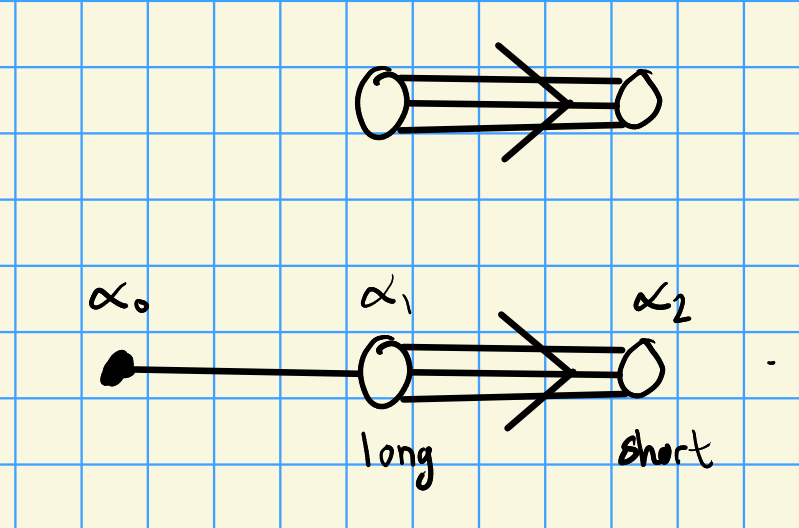

Here taking

- $\emptyset$ yields the Iwahori,
- $\left\{{ \alpha_1, \alpha_2}\right\}$ yields $G({\mathcal{O}}_x)$
- $\left\{{ \alpha_0, \alpha_1}\right\}$ yields $P\twoheadrightarrow{\operatorname{SL}}_3$
- $\left\{{\alpha_0, \alpha_2}\right\}: Q\twoheadrightarrow{\operatorname{SO}}_4 = ({\operatorname{SL}}_2\times {\operatorname{SL}}_2)/\Delta(\pm I)$.

# 16 Zhiwei Yun, Lecture 2

Today: what is rigidity?

## 16.1 Automorphic Data

Given the following:

- $k = {\mathbb{F}}_q$
- $S \subseteq {\left\lvert {X} \right\rvert}$ a finite set, e.g. $X= {\mathbb{P}}^1$ and $S = \left\{{0, \infty}\right\}$ or $S=\left\{{0,1,\infty}\right\}$.
- For each $x\in S$, a compact open $K_x \subseteq G(F_x)$
- For each $x\in S$, a character:

[figure not shown]

> [Link to Diagram](https://q.uiver.app/?q=WzAsMyxbMCwwLCJLX3giXSxbMiwwLCJcXENDXFx1bml0cyJdLFsxLDIsIkxfXFxjaGkgXFx0ZXh0eyBmaW5pdGV9Il0sWzAsMl0sWzIsMV0sWzAsMSwiXFxjaGkiLDJdXQ==)

The pair $(K_S, \chi_S)$ is **automorphic data**.

Note that $\chi_S = 1$ recovers $f\in {\mathcal{A}}_K$ where $K = K_S \times \prod_{x\not\in S} G({\mathcal{O}}_x)$.

A map
$$\begin{align*}
f\in C^0(\dcoset{G(F)} {G({\mathbb{A}})} {\prod_{x\not\in S} G({\mathcal{O}}_x) } \to {\mathbb{C}})
\end{align*}
is \((K_S, \chi_X){\hbox{-}}\)typical iff
\begin{align*}
f(gk_x) = \chi_x(k_x) f(g)\qquad \forall x\in S, k_x\in K_x, g\in G({\mathbb{A}})
.\end{align*}$$

We want to make $\dim {\mathcal{A}}_c(K_S,\chi_S) = 1$. In this case, the Hecke algebra ${\mathcal{H}}_{K_y} \curvearrowright f\in {\mathcal{A}}_c(K_S, \chi_S)$ by a character, making $f$ a Hecke eigenform.

## 16.2 Examples of naive ridigidy

Let

- $X={\mathbb{P}}^1$,
- $G = {\operatorname{SL}}_2$,
- $S=\left\{{0, 1,\infty}\right\}$,
- $K_x = I_x$ Iwahori for all $x\in S$, where
  $$\begin{align*}
  I_x = \left\{{A\mathrel{\vcenter{:}}={
  \begin{bmatrix}
  {a} & {b}
  \\
  {c} & {d}
  \end{bmatrix}
  } \in \operatorname{Mat}_{2}({\mathcal{O}}_X) {~\mathrel{\Big\vert}~}c\in {\mathfrak{m}}_x}\right\}
  .\end{align*}$$

Then choosing characters $\chi_x: k^{\times}\to {\mathbb{C}}^{\times}$ *generically* will imply $\dim {\mathcal{A}}_c(K_S, \chi_S) = 1$. Here generic means that $\prod \chi_i^{\pm 1}\neq 1$. By global Langlands for ${\operatorname{SL}}_2$, any $f\in {\mathcal{A}}_c(K_S, \chi_S)$ will yield a 2-dimensional local system on ${\mathbb{P}}^1\setminus\left\{{ 0,1,\infty }\right\}$ ramified at the 3 punctures. These will be solutions to hypergeometric differential equations.

For $G=\operatorname{PGL}_2$ (where the example works similarly), for $\chi_0, \chi_1 = 1$ and $\chi_\infty$ quadratic, there is a cover

[figure not shown]

Moreover $\left\{{H^1(E_t)}\right\}$ will be a rank 2 local system on this base.

Let

- $X = {\mathbb{P}}^1$
- $S = \left\{{0, \infty}\right\}$
- $K_0 = I_0$, $\chi_0 =1$
- $\tau$ a uniformizer at $\infty$
- $K_\infty = I_\infty^+ = \left\{{{ \begin{bmatrix} {a} & {b} \\ {c} & {d} \end{bmatrix} } {~\mathrel{\Big\vert}~}a\equiv d\equiv 1 \operatorname{mod}{\mathfrak{m}}_x, b\in {\mathcal{O}}_x, c\in {\mathfrak{m}}_x}\right\}$, the pro $p$ part

## 16.3 Naive Rigidity

$$\begin{align*}
(K_S, \chi_S) \text{ is rigid }\iff \dim {\mathcal{A}}_c(K_S, \chi_S) = 1
.\end{align*}$$

If $\pi_1 G\neq 1$, then $\pi_0 {\mathsf{Bun}}_G\geq 2$, yielding multiple components. It’s also not clear if this type of dimension bound will hold after a base change $k\to k'$.

## 16.4 Base Change

For $k'/k$ finite, write $X'\mathrel{\vcenter{:}}= X\otimes_k k'$ for the base change. Let $S\to S'$ be the preimage of $S$ in $S'$, and consider $k'_x \mathrel{\vcenter{:}}= K_x\otimes_k k'$ How can we base change a character? We need a norm map to fill in the following diagram:

[figure not shown]

> Link to Diagram

[figure not shown]

> Link to Diagram

Here $I_x(k') = \left\{{a,b,c,d\in {\mathcal{O}}_x\widehat{\otimes} k' \cong k'{\left[\left[ t \right]\right] }}\right\}$.

[figure not shown]

> Link to Diagram

We now geometrize this process to send characters to character sheaves, i.e. rank one local systems on $K_x$. We have a way of taking $(K_S, \chi_S)$ to $(K'_S, \chi_S')$ for extensions $K\to K'$, so we can form ${\mathcal{A}}(k'; K'_S, \chi'_S)$.

Automorphic data $(K_S, \chi_S)$ is **weakly rigid** iff $\dim {\mathcal{A}}_c(k'; K'_S, \chi_S')$ is uniformly bounded for all extensions $k\to k'$.

## 16.5 Relevant Points

Recall that there is a bijection
$$\begin{align*}
\dcoset{G(F)}{G({\mathbb{A}})}{K} \rightleftharpoons{\mathsf{Bun}}_G(K)(k)
,\end{align*}
so functions \(f\in {\mathcal{A}}_c(K_S, \chi_S)\) are functions on \({\mathsf{Bun}}_G(K_S^+)(k)\) where for \(x\in S\), \(K^+_x {~\trianglelefteq~}K_x\) with \({ \left.{{\chi_x}} \right|_{{K_x^+}} } = 1\) and \(K_x/K_x^+\) are the \(k{\hbox{-}}\)points of a finite dimensional group \(L_x\).$$

$I_x^+{~\trianglelefteq~}I_x = K_x \to {\mathbb{G}}_m(k)$.

$I_\infty^{++} = K_\infty^+ {~\trianglelefteq~}I_\infty^+ = K_\infty \to k{ {}^{ \scriptscriptstyle\oplus^{2} } }$ where ${ \begin{bmatrix} {a} & {b} \\ {c} & {d} \end{bmatrix} } \mapsto \qty{b, {c\over \tau}} \operatorname{mod}\tau$.

There is a right action
$$\begin{align*}
C^0({\mathsf{Bun}}_G(K_S^+)(k) \to {\mathbb{C}}?) \curvearrowleft\prod_{x\in S} L_x(k)
,\end{align*}
and the eigenfunctions with eigenvalues \((\chi_x)_{x\in S}\) are in \({\mathcal{A}}_c(K_S, \chi_S)\). As a set, \({\mathsf{Bun}}_G(K_S^+)\) has commuting left and right actions, where quotienting by the right action yields a principal homogeneous space. The left action is by \(\mathop{\mathrm{Aut}}({\mathcal{E}})\) for \({\mathcal{E}}\in {\mathsf{Bun}}_G(K_S)\), and permutes points in the fiber in \(\tilde {\mathcal{E}}\in {\mathsf{Bun}}_G(K_S^+)\). So there is an evaluation map which is well-defined up to conjugacy
\begin{align*}
\operatorname{ev}_{\mathcal{E}}: \mathop{\mathrm{Aut}}({\mathcal{E}}) \to \prod_{x\in S} L_x(k)
.\end{align*}$$

A $k{\hbox{-}}$point ${\mathcal{E}}\in {\mathsf{Bun}}_G(K_s)(k)$ is **$(K_S, \chi_S){\hbox{-}}$relevant** iff
$$\begin{align*}
{ \left.{{ \operatorname{ev}_{\mathcal{E}}^*\qty{ \prod_{x\in S} \chi_x } }} \right|_{{\mathop{\mathrm{Aut}}({\mathcal{E}})^0(k) }} } = 1
.\end{align*}
Similarly one can define relevant \(k'{\hbox{-}}\)points for \(k'/k\) a finite extension.$$

$$\begin{align*}
\dim {\mathcal{A}}_c(k'; K_S, \chi_S) \leq {\sharp}\operatorname{Rel}(K_S), \quad \operatorname{Rel}(K_S) \mathrel{\vcenter{:}}=\left\{{(K_S', \chi_S'){\hbox{-}}\text{relevant }k' \text{ points of } {\mathsf{Bun}}_G(K_S) }\right\}
.\end{align*}
Note that taking connected components in the definition is needed to make this stable under base change.$$

$(K_S, \chi_S)$ is weakly rigid $\iff {\sharp}\operatorname{Rel}(K_S) < \infty$.

Let

- $G={\operatorname{SL}}_2$
- $K_x = I_x$
- $x\in S \mathrel{\vcenter{:}}=\left\{{0, 1,\infty}\right\}$

Note that
$$\begin{align*}
{\mathsf{Bun}}_G(K_S)(k) = \left\{{ V\in \mathsf{VectBundle}^{\operatorname{rank}= 2}, \iota: \bigwedge\nolimits^2 V\cong {\mathcal{O}}_X, \left\{{\ell_x \subseteq V_x}\right\}_{x\in S} }\right\}
,\end{align*}
where the \(\ell\) are lines. So these are bundles with extra structure at fixed places, and are parameterized by 5-tuples \({\mathcal{E}}= (V, \iota, \ell_0, \ell_1, \ell_\infty)\). For all \(x\in S\) we have
\begin{align*}
I_x &\to {\mathbb{G}}_m = L_x \\
{
\begin{bmatrix}
{a} & {b}
\\
{c} & {d}
\end{bmatrix}
} &\mapsto a\operatorname{mod}\tau
,\end{align*}
and the evaluation map is \(\operatorname{ev}: \mathop{\mathrm{Aut}}({\mathcal{E}}) \to \prod_{x\in S} {\mathbb{G}}_m\). Each \(\gamma\in \mathop{\mathrm{Aut}}({\mathcal{E}})\) is a map \(V\to V\) where \(\gamma_0 \curvearrowright V_0\) preserving \(\ell_0\). Is it the case that
\begin{align*}
{ \left.{{\prod_{x\in S} \chi_x}} \right|_{{\mathop{\mathrm{Aut}}({\mathcal{E}})^0}} } \underset{?}{=} 1
.\end{align*}
For \(V = {\mathcal{O}}^2\) and \(\ell_x \subseteq k^2\) in generic position, \(\mathop{\mathrm{Aut}}({\mathcal{E}}) = \left\{{\pm 1}\right\}\) so they are relevant. Other points are irrelevant: if \(V = L \oplus L'\) with \(\ell_x\in L_x\) or \(L_x'\), \(\mathop{\mathrm{Aut}}({\mathcal{E}})\) will contain a copy of \({\mathbb{G}}_m\) that acts by scaling each \(L\) which will map nontrivially to \(\prod_{x\in S} {\mathbb{G}}_m\). Since \(\prod \chi_i^{\pm 1}\neq 1\), we get \({ \left.{{\operatorname{ev}_{\mathcal{E}}^* \prod \chi_x}} \right|_{{{\mathbb{G}}_m}} } \neq 1\).$$

# 17 Zhiwei Yun, Lecture 3

The Langlands correspondence:

| Automorphic | Galois |
| --- | --- |
| $G$ | $G {}^{ \vee }$ |
| Eigenforms $f\in {\mathcal{A}}_c(K_S, \chi_S)$ | Local systems, $\pi_1(X\setminus S) \to G {}^{ \vee }(\mkern 1.5mu\overline{\mkern-1.5mu{ {\mathbb{Q}}_\ell }\mkern-1.5mu}\mkern 1.5mu)$ |
| Rigid automorphic data | Rigid local systems |

Today we’ll discuss going from the automorphic side to the Galois side by designing rigid automorphic data.

## 17.1 Numerical Rigidity

Automorphic functions will be functions on the algebraic stack ${\mathsf{Bun}}_G(K_S)$, so we want to consider its $k{\hbox{-}}$points. This stack should have (possibly negative) dimension at most zero, what does this tell us about the level groups? For a curve $C$, there is a formula:
$$\begin{align*}
\dim {\mathsf{Bun}}_G(K_S) = 0 \iff \sum_{x\in S} [G({\mathcal{O}}_x): K_x] = (1-g(C))\dim G
,\end{align*}
where the brackets indicate relative dimension, which is always non-negative. Recall that \(I_x\) is a preimage of a Borel under reduction, and for \(K_x = I_x\) we have
\begin{align*}
[G({\mathcal{O}}_x): I_x] = \dim G({\mathcal{O}}_x)/I_x = \dim G/B = {\sharp}\Phi^+
.\end{align*}
If \(K_x\) is not contained in \(G({\mathcal{O}}_x)\), then
\begin{align*}
[G({\mathcal{O}}_x): K_x] = \dim G({\mathcal{O}}_x)/G({\mathcal{O}}_x) \cap K_x - \dim K_x/G({\mathcal{O}}_x) \cap K_x
.\end{align*}$$

The RHS in the formula is non-negative only when $g=0, 1$, so we expect most rigid data to come from ${\mathbb{P}}^1$. Genus 1 is a very special case, we get $K_x\sim G({\mathcal{O}}_x)$.

Consider

- $G$ a fixed group,
- $X = {\mathbb{P}}^1$,
- $S = \left\{{0,1,\infty}\right\}$,
- $K_x$ a parahoric.

Then
$$\begin{align*}
\dim G = \sum_{x=0,1,\infty} [G({\mathcal{O}}_x): K_x]
.\end{align*}
If \(K_x\) corresponds to a subdiagram of a Dynkin diagram, we can read off the reductive quotient \(L_x\) to get a surjective quotient map \(K_x\twoheadrightarrow L_x\). In this case,
\begin{align*}
[G({\mathcal{O}}_x): K_x] = {1\over 2}\qty{\dim G - \dim L_x}
.\end{align*}
The condition then becomes
\begin{align*}
\dim G = \sum_{x=0,1,\infty}\dim L_x
.\end{align*}$$

Consider the same setup for $G={\mathsf{G}}_2$.

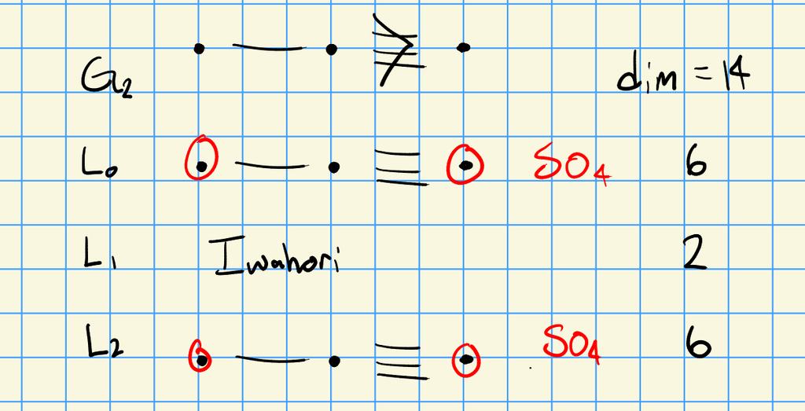

For $G = {\mathbf{E}}_8$, take $L_1$ to be the Iwahori and:

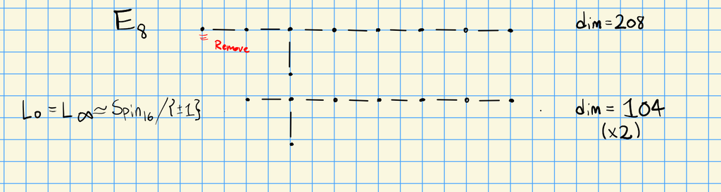

Idea: delete a node to try to get a group of roughly half-dimension. Cook up an order 2 character on the reductive quotient for $x=0$:

[figure not shown]

> Link to Diagram

Setting $\chi_\infty = \chi_1 = 1$, this yields automorphic datum which turns out to be rigid.

## 17.2 Matching with local monodromy

Given a local system, restrict to a formal neighborhood of a puncture to get a representation of the local Galois group, which we can restrict to inertia:

[figure not shown]

> Link to Diagram

If $K_x = I_x$ and one forms the character $K_x\to T(k)\to \mkern 1.5mu\overline{\mkern-1.5mu{ {\mathbb{Q}}_\ell }\mkern-1.5mu}\mkern 1.5mu^{\times}$, the representation $\rho_x$ is tamely ramified. There is a canonical map to the residue field ${\mathrm{In}}_x \to k_x^{\times}$, and $\chi$ can be turned into a morphism $k_x^{\times}\to T {}^{ \vee }(\mkern 1.5mu\overline{\mkern-1.5mu{ {\mathbb{Q}}_\ell }\mkern-1.5mu}\mkern 1.5mu^{\times})$ to the dual torus. The composite dual character ${\mathrm{In}}_x \to k_x^{\times}\to T {}^{ \vee }(\mkern 1.5mu\overline{\mkern-1.5mu{ {\mathbb{Q}}_\ell }\mkern-1.5mu}\mkern 1.5mu^{\times})$ has finite order and yields the semisimplification $({ \left.{{\rho_x}} \right|_{{{\mathrm{In}}_x}} })^{{\mathrm{ss}}}$. This yields unipotent monodromy, usually “maximally” nontrivial.

For $K_x = I_x^+ = \left\{{{ \begin{bmatrix} {a} & {b} \\ {c} & {d} \end{bmatrix} } {~\mathrel{\Big\vert}~}a-1,d-1,c\equiv 0 \operatorname{mod}t}\right\}$, one gets a character:

[figure not shown]

> [Link to Diagram](https://q.uiver.app/?q=WzAsNSxbMCwwLCJLX3g9SV94XisiXSxbMiwwLCJrIl0sWzQsMCwiXFxDQ1xcdW5pdHMiXSxbMCwxLCJcXG1hdHQgYSBiIGMgZCJdLFsyLDEsImIgKyB7Y1xcb3ZlciB0fVxcbW9kIHQiXSxbMSwyLCJcXHBzaSJdLFswLDFdXQ==)

One gets a wildly ramified representation:
$$\begin{align*}
\rho_x: { \mathsf{Gal}} (\mkern 1.5mu\overline{\mkern-1.5muF\mkern-1.5mu}\mkern 1.5mu_x/F_x)\to \operatorname{GL}_2(\mkern 1.5mu\overline{\mkern-1.5mu{ {\mathbb{Q}}_\ell }\mkern-1.5mu}\mkern 1.5mu)
.\end{align*}
The Swan conductor is \({\mathrm{Sw}}(\rho_x) = 1 = {1\over 2} + {1\over 2}\), where the first factor comes from the shape of the level group \(I_x^+\). There is a Moy-Prasad filtration on \(I_x\) indexed by \({1\over h}{\mathbb{Z}}\) for \(h\) the Coxeter number of \(G\), which for \(G={\operatorname{SL}}_2\) yields \(h=2\). The filtration is$$

[figure not shown]

> Link to Diagram

If $K_x \subseteq P_x(r)$ for $r\in {\mathbb{Q}}$, then all slopes of $\rho_x$ are at most $r$, bounding the ramification. In this case depth matches up with slopes.

Ansatz for finding correct automorphic data: if $(K_S, \chi_S)$ is rigid and $\rho: \pi_1\to G {}^{ \vee }$, there should be an equality involving $a$ the Artin conductor:
$$\begin{align*}
[G({\mathcal{O}}_x): K_x] = {1\over 2} a({ \operatorname{Ad} }\rho_x)
.\end{align*}$$

Let

- $S = \left\{{0, \infty}\right\}$,
- $K_0 = P_0$ a parahoric,
- $K_\infty = P_\infty^+$ the pro-unipotent of some parahoric
- $\chi: k\to {\mathbb{C}}^{\times}$ be an additive character

Compose to get a character $P_\infty^+ \xrightarrow{?} k \xrightarrow{\psi} {\mathbb{C}}^{\times}$, where the missing morphism is the interesting bit. For $G = {\mathsf{Sp}}_{2n} = {\mathsf{Sp}}(V)$, a Siegel parabolic is the stabilizer of a Lagrangian subspace in $V$ and has the following shape:

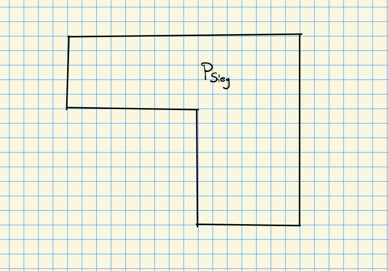

Write this as $P_{\mathrm{Sieg}}$ preserving a Lagrangian $L$ and take its transpose to get $P_{\mathrm{Sieg}}^{\operatorname{op}}$ which preserves a complementary Lagrangian subspace $L^c \cong L {}^{ \vee }$. Let $P_0 \subseteq G({\mathcal{O}}_0), P_\infty \subseteq G({\mathcal{O}}_\infty)$ be the associated parahorics. Define a map
$$\begin{align*}
P_\infty^+ = \left\{{{
\begin{bmatrix}
{A} & {B}
\\
{C} & {D}
\end{bmatrix}
} \in G({\mathcal{O}}_\infty) {~\mathrel{\Big\vert}~}A-I, D-I, C\equiv 0 \operatorname{mod}\tau}\right\}
&\to W = \operatorname{Sym}^2(L) \oplus \operatorname{Sym}^2(L {}^{ \vee }) \\
{
\begin{bmatrix}
{A} & {B}
\\
{C} & {D}
\end{bmatrix}
} &\mapsto \qty{B\operatorname{mod}\tau, {C\over \tau} \operatorname{mod}\tau}
.\end{align*}$$

We then have

- $\mkern 1.5mu\overline{\mkern-1.5muA\mkern-1.5mu}\mkern 1.5mu\in \operatorname{GL}(L)$
- $\mkern 1.5mu\overline{\mkern-1.5muD\mkern-1.5mu}\mkern 1.5mu\in \operatorname{GL}(L {}^{ \vee })$
- $\mkern 1.5mu\overline{\mkern-1.5muB\mkern-1.5mu}\mkern 1.5mu: L {}^{ \vee }\to L$ self-dual, so $\mkern 1.5mu\overline{\mkern-1.5muB\mkern-1.5mu}\mkern 1.5mu {}^{ \vee }= \mkern 1.5mu\overline{\mkern-1.5muB\mkern-1.5mu}\mkern 1.5mu$,
- $C/\tau: L\to L {}^{ \vee }$ a self-adjoint operator

We can further apply the trace pairing, fixing $S\in \operatorname{Sym}^2(L)$ and $T\in \operatorname{Sym}^2(L {}^{ \vee })$:
$$\begin{align*}
\operatorname{Trace}: W\to k \\
(X, Y) &\mapsto \operatorname{Trace}(XT) + \operatorname{Trace}(YS)
.\end{align*}
Choosing a pair \((S, T)\) yields a character:
\begin{align*}
P_\infty^+ \to W \xrightarrow{(S, T)} k \xrightarrow{\psi} {\mathbb{C}}^{\times}
.\end{align*}
Stable pairs \((S, T)\) will yield rigid data, where stable is the open condition that \(ST\in \mathop{\mathrm{End}}(L)\) has distinct nonzero eigenvalues in \(\mkern 1.5mu\overline{\mkern-1.5muk\mkern-1.5mu}\mkern 1.5mu\), so regular semisimple and invertible.$$

Epipelagic reps of $G(F_\infty)$ due to Reeder-J-K. Yu: for ${\mathsf{Sp}}_{2n}$ this amounts to choosing a matrix of the following shape with equally sized blocks:

[figure not shown]

# 18 Zhiwei Yun, Lecture 4

## 18.1 Kloosterman Automorphic Systems

We’ve just been on the automorphic side: today we harvest on the Galois side! For $(K_S, \chi_S)$ automorphic data, there is a Hecke action
$$\begin{align*}
f\in {\mathcal{A}}_c(K_S,\chi_S) \curvearrowleft{\mathcal{H}}_{K_x},\quad x\in {\left\lvert {X} \right\rvert} \setminus S
.\end{align*}
The Satake isomorphism yields a correspondence
\begin{align*}
\left\{{\text{Functions } {\mathcal{H}}_{K_x} \to \mkern 1.5mu\overline{\mkern-1.5mu{ {\mathbb{Q}}_\ell }\mkern-1.5mu}\mkern 1.5mu}\right\}
\rightleftharpoons
\left\{{\text{Semisimple conjugacy classes in } \widehat{G}(\mkern 1.5mu\overline{\mkern-1.5mu{ {\mathbb{Q}}_\ell }\mkern-1.5mu}\mkern 1.5mu)}\right\}
.\end{align*}
So for all places \(x\not\in S\), one gets a Satake parameter \(\sigma_x\in \widehat{G}_{{\mathrm{ss}}}(\mkern 1.5mu\overline{\mkern-1.5mu{ {\mathbb{Q}}_\ell }\mkern-1.5mu}\mkern 1.5mu)\). By Langlands, there exists a representation \(\rho: \pi_1(X\setminus S) \to \widehat{G}(\mkern 1.5mu\overline{\mkern-1.5mu{ {\mathbb{Q}}_\ell }\mkern-1.5mu}\mkern 1.5mu)\) such that \(\rho(\operatorname{Frob}_x)^{{\mathrm{ss}}} \sim \sigma_x\). How do you construct \(\rho\) from \(f\)?$$

We’ll geometrize this along the lines of Drinfeld, Laumon, etc. Set $G=\operatorname{GL}_n$ and let $T_x\in {\mathcal{H}}_{K_x}$ be the characteristic function on $K_x \operatorname{diag}(t_x, 1,\cdots, 1) K_x$. For $f: {\mathsf{Bun}}_G(k)\to \mkern 1.5mu\overline{\mkern-1.5mu{ {\mathbb{Q}}_\ell }\mkern-1.5mu}\mkern 1.5mu$, define an operator
$$\begin{align*}
(T_x f)({\mathcal{E}}) \mathrel{\vcenter{:}}=\sum_{{\mathcal{E}}' \hookrightarrow{\mathcal{E}}\text{ length 1 at } x} f({\mathcal{E}}')
.\end{align*}
Note that the index set is isomorphic to \({\mathbb{P}}({\mathcal{E}}_x)\). This translates functions to sheaves: summing corresponds to taking cohomology, characters become character sheaves. Let \({\mathsf{Hk} }^1 = \left\{{{\mathcal{E}}' \to {\mathcal{E}}\text{ of length 1}}\right\}\), then there is a span:$$

[figure not shown]

> [Link to Diagram](https://q.uiver.app/?q=WzAsMyxbMCwyLCJcXEJ1bl9HIl0sWzIsMCwiXFxIa14xIl0sWzQsMiwiXFxCdW5fR1xcdGltZXMgKFhcXHNtIFMpIl0sWzEsMCwiaF8xIiwyXSxbMSwyLCJoXzIiXV0=)

The operator $T_x$ geometrizes in the following way: \begin{align*} T_1 {\mathcal{F}}\mathrel{\vcenter{:}}=(h_2){}_{!}(h_1{}^{*}{\mathcal{F}}) \in {\mathsf{Sh}}({\mathsf{Bun}}_G\times (X\setminus S)) ,\end{align*} and being an *eigensheaf* translates $T_x f = \lambda_x f$ for $\lambda_x\in \mkern 1.5mu\overline{\mkern-1.5mu{ {\mathbb{Q}}_\ell }\mkern-1.5mu}\mkern 1.5mu$ to the condition
$$\begin{align*}
T_1{\mathcal{F}}= {\mathcal{F}}\boxtimes E
.\end{align*}
The goal is to compute \(E\); this will yield
\begin{align*}
\operatorname{Trace}(\operatorname{Frob}_x; E) = \lambda_x \qquad\forall x\in X\setminus S
.\end{align*}$$

Benedict Gross constructed $\operatorname{Kl}$ automorphic datum, showed rigidity using a trace formula, and conjectured some properties of $\rho$ related to a Kloosterman local system. Heinloth-Ngo-Y. constructed this $\rho$, uncovering the story of rigidity here.

Let

- $G = \operatorname{PGL}_n$
- The 0-level $K_0 = I_0$ is the Iwahori and $\chi_0 = 1$
- The infinity level $K_\infty = I_\infty^+$, and the character is given in the following way: add superdiagonal and lower-left corner mod $\tau$ (the uniformizer at $\infty$), so
  $$\begin{align*}
  (a_{ij}) \mapsto \sum a_{i, i+1} + {a_{n, 1} \over \tau} \operatorname{mod}\tau \leadsto I_{\infty}^+ \to k \xrightarrow{\psi} \mkern 1.5mu\overline{\mkern-1.5mu{ {\mathbb{Q}}_\ell }\mkern-1.5mu}\mkern 1.5mu^{\times}
  .\end{align*}$$

In this case,
$$\begin{align*}
{\mathsf{Bun}}_G(K_0, K_\infty) = \left\{{
\begin{array}{l}
V\in { {\mathsf{Bun}}\qty{\operatorname{GL}_r} }^{\operatorname{rank}= n}({\mathbb{P}}^1), \\
F^n \supseteq F^{n-1} \supseteq\cdots\supseteq F^1 \text{ a full flag on } V_0, \\
F_0 \subseteq F_1 \subseteq \cdots\subseteq F^n \text{a full flag on }V_\infty, \\
\left\{{e_i}\right\} \text{a basis of }{\mathsf{gr}\,}_i (F_\bullet)
\end{array}
}\right\}/{\operatorname{Pic}}
.\end{align*}
There is a unique relevant point on each component of \({\mathsf{Bun}}_G(K_0, K_\infty)\), where \(\deg V \operatorname{mod}n\) is well-defined. It’s given by \({\mathcal{E}}_0\) where \({\mathcal{O}}{ {}^{ \scriptscriptstyle\oplus^{n} } } = \bigoplus_{i\leq n} {\mathcal{O}}_i\), with a flag \(\left\{{e_n}\right\}, \left\{{e_n, e_{n-1}}\right\},\cdots\). One can show that \(\mathop{\mathrm{Aut}}({\mathcal{E}}_0) = 1\) making it automatically relevant.$$

A point ${\mathcal{E}}_1$ yields $\bigoplus_{k\leq n-1} {\mathcal{O}}e_k \oplus {\mathcal{O}}(1)e_n$, with flags

- $F^\bullet: \left\{{e_{n-1}}\right\}, \left\{{e_{n-1}, e_{n-2}}\right\},\cdots$.
- $F_\bullet: \left\{{e_1}\right\}, \left\{{e_1, e_2}\right\}, \cdots$

There is a Hecke stack ${\mathsf{Hk} }$ containing $\left\{{\phi: {\mathcal{E}}_0 \hookrightarrow{\mathcal{E}}_1}\right\}$, and a span:

[figure not shown]

> Link to Diagram

Pull-push yields a local system. Similarly:

[figure not shown]

> [Link to Diagram](https://q.uiver.app/?q=WzAsMyxbMCwyLCJcXEFBXjEiXSxbMiwwLCJcXEdHX21cXGNhcnRwb3dlcntufSJdLFs0LDIsIlxcR0dfbSJdLFsxLDIsIlxccGkgPSBcXHRleHR7cHJvZH0iXSxbMSwwLCJcXHNpZ21hID0gXFx0ZXh0e3N1bX0iLDJdXQ==)

Defining $E \mathrel{\vcenter{:}}={\mathbb{R}}^{n-1} \pi{}_{!}\sigma{}^{*}\mathrm{AS}_\psi \in \mathsf{LocSys}^{\operatorname{rank}= n}$ exactly recovers Deligne’s Kloosterman sheaf.

For more general $G$, ${\mathcal{H}}_{K_x}$ has a Kazhdan basis $C_\lambda$, where dominant weights $\lambda \in X_*(T)$ correspond to irreducible reps of $G {}^{ \vee }$. Taking $T_x$ for $\operatorname{GL}_n$ recovers the standard representation of $G {}^{ \vee }= \operatorname{GL}_n$. The geometric incarnation of the Hecke operator is $T_\lambda F$:

[figure not shown]

> Link to Diagram

Here ${\mathcal{F}}$ is an eigensheaf, so $T_\lambda {\mathcal{F}}= {\mathcal{F}}\boxtimes E_\lambda$. Note that the $\operatorname{\mathcal{IC}}$ sheaf is not always constant.

$\lambda \mapsto E_\lambda$ comes from a $\widehat{G}{\hbox{-}}$local system on $X\setminus S$:

[figure not shown]

> [Link to Diagram](https://q.uiver.app/?q=WzAsMyxbMCwwLCJcXHBpXzEoWFxcc20gUykiXSxbMiwwLCJcXGhhdCBHIl0sWzIsMiwiXFxHTChWX1xcbGFtYmRhKSJdLFswLDEsIlxccmhvIl0sWzEsMl0sWzAsMiwiRV9cXGxhbWJkYSIsMl1d)

## 18.2 Applications

If $(K_S, \chi_S)$ is “tame,” where $K_x$ is parahoric, this data will make sense over any base field $k$ which $\chi_S$ is replaced by a character sheaf. Note that this only works for multiplicative characters, since additive characters depend on characteristic. One can construct these Hecke eigensheaves and $G {}^{ \vee }$ local systems for arbitrary fields, e.g. for ${\mathbb{P}}^1_{/ {{\mathbb{Q}}}} \setminus S$ where there may not even be a theory of automorphic forms. A first example constructs an ${\mathbf{E}}_8{\hbox{-}}$local system on ${\mathbb{P}}^1_{/ {{\mathbb{Q}}}} \setminus\left\{{ 0,1,\infty }\right\}$, yielding a motive whose motivic Galois group is ${\mathbf{E}}_8$. One can then apply this to the inverse Galois problem, arguing that there exists a number field $K$ such that
$$\begin{align*}
{ \mathsf{Gal}} (K/{\mathbb{Q}}) \cong {\mathbf{E}}_8({\mathbb{F}}_\ell), \qquad \ell \gg 0
.\end{align*}$$

See the notes for relations to “rigidity methods” in inverse Galois theory.

## 18.3 Open Problems

Classification: say $G=\operatorname{GL}_n$, can one classify all rigid automorphic data?

These should correspond under Langlands to rigid local systems, where there is an algorithmic classification due to Katz in the tame case and Arinkin in general. One can start with rank 1 local systems and apply one of three simple procedures to get local systems of higher rank. Note that hypergeometric local systems occur.

Is there an algorithmic way of producing automorphic data?

Is there a uniform way to check rigidity?

Checking rigidity requires knowing the specific geometry of ${\mathsf{Bun}}_G$ and some tricky linear algebra. There are some results that provide the uniform bound on dimensions ${\mathcal{A}}_c$ needed to prove weak rigidity.

Can ${\mathcal{A}}_c(K_S, \chi_S)$ be further decomposed into Hecke modules when the dimension is bigger than 1?

This dimension can grow exponentially.

# 19 Saturday, March 05

Goal: proving rigidity. Start with example 2.1.5 in the notes on Kloosterman automorphic data.

# 20 Bibliography

[^1]: This is already interesting in the case of $X = {\mathbb{P}}^1$.